# Sparkify Project Workspace

This workspace uses a subset of data `medium-sparkify-event-data.json` (256MB) of the full available dataset (12GB).

```python
import ibmos2spark
# @hidden_cell
credentials = {
    'endpoint': 'https://s3-api.us-geo.objectstorage.service.networklayer.com',
    'service_id': 'iam-ServiceId-095a6003-6269-486e-8bf7-22f7856e2a33',
    'iam_service_endpoint': 'https://iam.cloud.ibm.com/oidc/token',
    'api_key': '5rd4JjbLDtIKnWhmwbTnQGOA7c5tDfii-FOwpOKtsX-V'
}

configuration_name = 'os_2746aaba51d24cd3a479f8d2da307b1d_configs'
cos1 = ibmos2spark.CloudObjectStorage(sc, credentials, configuration_name, 'bluemix_cos')
```

```python
# import libraries
from pyspark.sql import SparkSession
from pyspark.sql import DataFrame
from pyspark.sql.functions import avg
from pyspark.sql.functions import col
from pyspark.sql.functions import concat
from pyspark.sql.functions import desc
from pyspark.sql.functions import explode
from pyspark.sql.functions import lit
from pyspark.sql.functions import min
from pyspark.sql.functions import max
from pyspark.sql.functions import split
from pyspark.sql.functions import udf
from pyspark.sql.functions import when
from pyspark.sql.functions import isnan
from pyspark.sql.functions import count
from pyspark.sql.functions import dayofyear
from pyspark.sql.functions import *
from pyspark.sql.types import IntegerType
from pyspark.sql.types import FloatType
from pyspark.sql.types import StringType
from pyspark.sql.types import ArrayType

from pyspark.ml import Pipeline
from pyspark.ml.feature import RegexTokenizer
from pyspark.ml.feature import VectorAssembler
from pyspark.ml.feature import CountVectorizer
from pyspark.ml.feature import IDF
from pyspark.ml.feature import Normalizer
from pyspark.ml.feature import PCA
from pyspark.ml.feature import StandardScaler
from pyspark.ml.feature import StopWordsRemover
from pyspark.ml.feature import StringIndexer

from pyspark.ml.regression import LinearRegression
from pyspark.ml.classification import LogisticRegression
from pyspark.ml.classification import RandomForestClassifier
from pyspark.ml.classification import GBTClassifier
from pyspark.ml.classification import DecisionTreeClassifier
from pyspark.ml.classification import LinearSVC
from pyspark.ml.classification import NaiveBayes
from pyspark.ml.classification import MultilayerPerceptronClassifier
from pyspark.ml.evaluation import MulticlassClassificationEvaluator
from pyspark.ml.evaluation import BinaryClassificationEvaluator

from pyspark.ml.linalg import Vectors
from pyspark.ml.linalg import VectorUDT
from pyspark.ml.linalg import SparseVector
from pyspark.ml.linalg import DenseVector
from pyspark.ml.feature import VectorAssembler
from pyspark.ml.feature import MaxAbsScaler
from pyspark.ml.feature import StandardScaler

from pyspark.ml.tuning import CrossValidator
from pyspark.ml.tuning import ParamGridBuilder

from os import path

import re

import datetime

import numpy as np
import pandas as pd
%matplotlib inline
import matplotlib.pyplot as plt
import seaborn as sbn

from IPython.core.display import display, HTML

try:
    import cPickle as pickle
except:
    import pickle

import requests
```

```python
nt0 = pd.Timestamp.now()
print('NoteBook execution start time : {}'.format(nt0))
```

```
NoteBook execution start time : 2020-08-08 09:25:26.002904
```

```python
! pip install sparksql-magic
```

[output not shown]

```python
%reload_ext sparksql_magic
```

```python
# create a Spark session
from pyspark.sql import SparkSession
spark = SparkSession.builder.getOrCreate()

df = spark.read.json(cos1.url('medium-sparkify-event-data.json', 'sparkify-donotdelete-pr-42ldwg6hxv8yav'))
df.show(2)
```

```
+-----------------+---------+---------+------+-------------+--------+---------+-----+--------------------+------+--------+-------------+---------+-------------+------+-------------+--------------------+------+
|           artist|     auth|firstName|gender|itemInSession|lastName|   length|level|            location|method|    page| registration|sessionId|         song|status|           ts|           userAgent|userId|
+-----------------+---------+---------+------+-------------+--------+---------+-----+--------------------+------+--------+-------------+---------+-------------+------+-------------+--------------------+------+
|    Martin Orford|Logged In|   Joseph|     M|           20| Morales|597.55057| free|  Corpus Christi, TX|   PUT|NextSong|1532063507000|      292|Grand Designs|   200|1538352011000|"Mozilla/5.0 (Mac...|   293|
|John Brown's Body|Logged In|   Sawyer|     M|           74|  Larson|380.21179| free|Houston-The Woodl...|   PUT|NextSong|1538069638000|       97|        Bulls|   200|1538352025000|"Mozilla/5.0 (Mac...|    98|
+-----------------+---------+---------+------+-------------+--------+---------+-----+--------------------+------+--------+-------------+---------+-------------+------+-------------+--------------------+------+
only showing top 2 rows
```

```python
df = df.withColumn('day', dayofyear(from_unixtime(df.ts/1000, 'yyyy-MM-dd')))
```

```python
df.show(2)
```

```
+-----------------+---------+---------+------+-------------+--------+---------+-----+--------------------+------+--------+-------------+---------+-------------+------+-------------+--------------------+------+---+
|           artist|     auth|firstName|gender|itemInSession|lastName|   length|level|            location|method|    page| registration|sessionId|         song|status|           ts|           userAgent|userId|day|
+-----------------+---------+---------+------+-------------+--------+---------+-----+--------------------+------+--------+-------------+---------+-------------+------+-------------+--------------------+------+---+
|    Martin Orford|Logged In|   Joseph|     M|           20| Morales|597.55057| free|  Corpus Christi, TX|   PUT|NextSong|1532063507000|      292|Grand Designs|   200|1538352011000|"Mozilla/5.0 (Mac...|   293|274|
|John Brown's Body|Logged In|   Sawyer|     M|           74|  Larson|380.21179| free|Houston-The Woodl...|   PUT|NextSong|1538069638000|       97|        Bulls|   200|1538352025000|"Mozilla/5.0 (Mac...|    98|274|
+-----------------+---------+---------+------+-------------+--------+---------+-----+--------------------+------+--------+-------------+---------+-------------+------+-------------+--------------------+------+---+
only showing top 2 rows
```

```python
df.createOrReplaceTempView("log_t")
```

# Load and Clean Dataset

In this workspace, the dataset file is `medium-sparkify-event-data.json`. Load and clean the dataset, checking for invalid or missing data - for example, records without userids or sessionids.

```python
df.printSchema()
```

```
root
 |-- artist: string (nullable = true)
 |-- auth: string (nullable = true)
 |-- firstName: string (nullable = true)
 |-- gender: string (nullable = true)
 |-- itemInSession: long (nullable = true)
 |-- lastName: string (nullable = true)
 |-- length: double (nullable = true)
 |-- level: string (nullable = true)
 |-- location: string (nullable = true)
 |-- method: string (nullable = true)
 |-- page: string (nullable = true)
 |-- registration: long (nullable = true)
 |-- sessionId: long (nullable = true)
 |-- song: string (nullable = true)
 |-- status: long (nullable = true)
 |-- ts: long (nullable = true)
 |-- userAgent: string (nullable = true)
 |-- userId: string (nullable = true)
 |-- day: integer (nullable = true)
```

```python
summary = spark.createDataFrame(df.describe().where("summary = 'count'").collect()).toPandas().head(10)
```

```python
summary.style.hide_index()
```

| summary | artist | auth | firstName | gender | itemInSession | lastName | length | level | location | method | page | registration | sessionId | song | status | ts | userAgent | userId | day |
| --- | --- | --- | --- | --- | --- | --- | --- | --- | --- | --- | --- | --- | --- | --- | --- | --- | --- | --- | --- |
| count | 432877 | 543705 | 528005 | 528005 | 543705 | 528005 | 432877 | 543705 | 528005 | 543705 | 543705 | 528005 | 543705 | 432877 | 543705 | 543705 | 528005 | 543705 | 543705 |

we can see that not all rows have equal number of count. This indicates that there are null values in each column. We can drop those null values especially in userId and page coulmn to get clean dataset for analysis

```python
df = df.filter(df.page.isNotNull()).filter(df.userId.isNotNull())
```

```python
summary1 = spark.createDataFrame(df.describe().where("summary = 'count'").collect()).toPandas().head(5)
```

```python
summary1.style.hide_index()
```

| summary | artist | auth | firstName | gender | itemInSession | lastName | length | level | location | method | page | registration | sessionId | song | status | ts | userAgent | userId | day |
| --- | --- | --- | --- | --- | --- | --- | --- | --- | --- | --- | --- | --- | --- | --- | --- | --- | --- | --- | --- |
| count | 432877 | 543705 | 528005 | 528005 | 543705 | 528005 | 432877 | 543705 | 528005 | 543705 | 543705 | 528005 | 543705 | 432877 | 543705 | 543705 | 528005 | 543705 | 543705 |

The dataset has only no null values in userIds, ts, status, page, level, itemInsession, auth. But there are other field like artist, lenght, song are found. Let us see if these are valid cases be have null values

```python
df.createOrReplaceTempView("log_table")
```

```python
spark.sql("select distinct(page) from log_table \
           where song is not null \
           and artist is not null \
           and length is not null \
        ").toPandas()
```

|  | page |
| --- | --- |
| 0 | NextSong |

It is understandable that field artist, lenght, song are log only for NextSong page where it makes sense. Let us find out why the fields like firstName, gender, lastname, registration, userAgent are not logged

```python
spark.sql("select distinct(auth) from log_table \
            where song is null ").toPandas()
```

|  | auth |
| --- | --- |
| 0 | Logged Out |
| 1 | Cancelled |
| 2 | Guest |
| 3 | Logged In |

```python
spark.sql("select distinct(auth) from log_table \
           where firstName is not null \
           and gender is not null \
           and lastName is not null \
           and registration is not null \
           and userAgent is not null \
        ").toPandas()
```

|  | auth |
| --- | --- |
| 0 | Cancelled |
| 1 | Logged In |

We could see the firstName, gender, lastname, registration, userAgent are not logged for users we were never registered. that is Guest users. This names sense as we will never have such details with out registering for the service . Now the data is good we start the Exploratory analysis

# Exploratory Data Analysis

When working with the full dataset, EDA is performed by loading a small subset of the data and doing basic manipulations within Spark.

### Define Churn

Churn can be defined as user leaving the service. This is indicated by presence of `Cancellation Confirmation` page. `Downgrade event` can also be early indicator of churn

After the EDA analysis a column `isCancelled` is use as the label for the model indicating user using the Cancellation Confirmation events to define churn, which happen for both paid and free users.

### Explore Data

Exploratory data analysis is done to observe the behavior for users who stayed vs users who churned. We can start by exploring aggregates on these two groups of users, observing how much of a specific action they experienced per a certain time unit or number of songs played.

Start with the pages users visited

```python
%%sparksql  -l 999

SELECT DISTINCT(page)
  FROM log_table
```

| page |
| --- |
| Cancel |
| Submit Downgrade |
| Thumbs Down |
| Home |
| Downgrade |
| Roll Advert |
| Logout |
| Save Settings |
| Cancellation Confirmation |
| About |
| Submit Registration |
| Settings |
| Login |
| Register |
| Add to Playlist |
| Add Friend |
| NextSong |
| Thumbs Up |
| Help |
| Upgrade |
| Error |
| Submit Upgrade |

###### As this is timeseriese data, Let us find the what is time period of data available

```python
spark.sql("select from_unixtime(min(ts)/1000) as start_date, \
                  from_unixtime(max(ts)/1000) as end_date \
          from log_table").toPandas().style.hide_index()
```

| start_date | end_date |
| --- | --- |
| 2018-10-01 00:00:11 | 2018-12-01 00:01:06 |

```python
%%sparksql -l 100
SELECT count(distinct( userId))
  FROM log_table
```

| count(DISTINCT userId) |
| --- |
| 449 |

```python
%%sparksql -l 100
SELECT COUNT(DISTINCT(userId))
  FROM log_t
 WHERE page = 'Cancel'
```

| count(DISTINCT userId) |
| --- |
| 99 |

```python
%%sparksql -l 100
SELECT
       (SELECT COUNT(DISTINCT(userId))
          FROM log_table
         WHERE page  = 'Register'
           AND level = 'free'
       ) AS Free_registered_users
      ,(SELECT COUNT(DISTINCT(userId))
          FROM log_table
         WHERE page  = 'Register'
           AND level = 'paid'
       ) AS Paid_registered_users
      ,(SELECT COUNT(DISTINCT(userId))
          FROM log_table
         WHERE page  = 'Upgrade'
           AND level = 'free'
       ) AS Upgraded_users
      ,(SELECT COUNT(DISTINCT(userId))
          FROM log_table
         WHERE page  = 'Downgrade'
           AND level = 'paid'
       ) AS Downgrade_users
      ,(SELECT COUNT(DISTINCT(userId))
          FROM log_table
         WHERE page  = 'Cancel'
           AND level = 'free'
       ) AS Free_cancelled_users
      ,(SELECT COUNT(DISTINCT(userId))
          FROM log_table
         WHERE page  = 'Cancel'
           AND level = 'paid'
       ) AS paid_cancelled_users
  FROM log_table
 LIMIT 1
```

| Free_registered_users | Paid_registered_users | Upgraded_users | Downgrade_users | Free_cancelled_users | paid_cancelled_users |
| --- | --- | --- | --- | --- | --- |
| 1 | 0 | 315 | 301 | 32 | 67 |

The above counts of user indicate how users actions over the timeperiod of the dataset. There is overlap between these buclekts of user. So total user here will be more than the total distinct user we found in the dataset. Let us find the distribution of cancelled users by listening time and time since registered and frequency of Advert Rolls. I believe these factors could gauge the interest of the user to stick on to the service as paid user

###### First let us look at the per user listening time per week for cancelled and registered user by paid and free user levels. This gives us a view of how much time user spends on listening to song each week

```python
df_c = spark.sql('''
-- cancelled user
SELECT weekofyear(from_unixtime(a.ts/1000, 'yyyy-MM-dd')) as week
      ,a.level
      ,sum(a.length) as listen_time_cancelled_user
      ,count(distinct(a.userId)) as user_C
  FROM log_table a
      ,log_table b
 WHERE a.userId = b.userId
   AND a.page = 'NextSong'
   AND b.page = 'Cancel'
 GROUP by week
         ,a.level
 ORDER by week
         ,a.level
''').toPandas()
```

```python
df_r = spark.sql('''
-- Registered users
SELECT weekofyear(from_unixtime(a.ts/1000, 'yyyy-MM-dd')) as week
      ,a.level
      ,sum(a.length) as listen_time_Registered_user
      ,count(distinct a.userId) as user_R
  FROM log_table a
 WHERE a.page = 'NextSong'
   AND a.userId not in
       ( select userId from log_table b
          where page = 'Cancel'
            and a.userId = b.userId
       )
 GROUP by week
      ,a.level
 ORDER by week
      ,a.level
''').toPandas()
```

```python
# Caputure the result of both the queries as pandas dataframe
df_listen = pd.merge(df_c, df_r, on=['week', 'level'])
```

```python
df_listen['prop_time_can_user'] = df_listen['listen_time_cancelled_user'] / df_listen['user_C']
df_listen['prop_time_reg_user'] = df_listen['listen_time_Registered_user'] / df_listen['user_R']
```

```python
df_listen.style.hide_index()
```

| week | level | listen_time_cancelled_user | user_C | listen_time_Registered_user | user_R | prop_time_can_user | prop_time_reg_user |
| --- | --- | --- | --- | --- | --- | --- | --- |
| 40 | free | 1.69592e+06 | 66 | 2.89248e+06 | 191 | 25695.7 | 15143.9 |
| 40 | paid | 1.7674e+06 | 38 | 4.40492e+06 | 90 | 46510.4 | 48943.6 |
| 41 | free | 1.10768e+06 | 51 | 2.62571e+06 | 155 | 21719.2 | 16940 |
| 41 | paid | 2.04283e+06 | 35 | 6.59373e+06 | 118 | 58366.5 | 55879.1 |
| 42 | free | 871995 | 40 | 2.19014e+06 | 132 | 21799.9 | 16592 |
| 42 | paid | 1.96696e+06 | 31 | 7.11088e+06 | 136 | 63450.4 | 52285.9 |
| 43 | free | 465580 | 24 | 1.56093e+06 | 121 | 19399.1 | 12900.2 |
| 43 | paid | 2.88527e+06 | 39 | 7.63962e+06 | 133 | 73981.3 | 57440.8 |
| 44 | free | 288481 | 14 | 1.70106e+06 | 122 | 20605.8 | 13943.1 |
| 44 | paid | 2.856e+06 | 40 | 8.84918e+06 | 147 | 71399.9 | 60198.5 |
| 45 | free | 300428 | 15 | 1.35461e+06 | 95 | 20028.5 | 14259.1 |
| 45 | paid | 2.24736e+06 | 36 | 1.06365e+07 | 156 | 62426.8 | 68182.7 |
| 46 | free | 245519 | 9 | 1.09301e+06 | 88 | 27279.8 | 12420.5 |
| 46 | paid | 1.19312e+06 | 21 | 9.80604e+06 | 161 | 56815.1 | 60907 |
| 47 | free | 93541.2 | 4 | 995626 | 85 | 23385.3 | 11713.2 |
| 47 | paid | 562361 | 11 | 9.36882e+06 | 159 | 51123.8 | 58923.4 |
| 48 | free | 38303.4 | 3 | 1.15728e+06 | 82 | 12767.8 | 14113.1 |
| 48 | paid | 376146 | 5 | 6.65577e+06 | 149 | 75229.2 | 44669.6 |

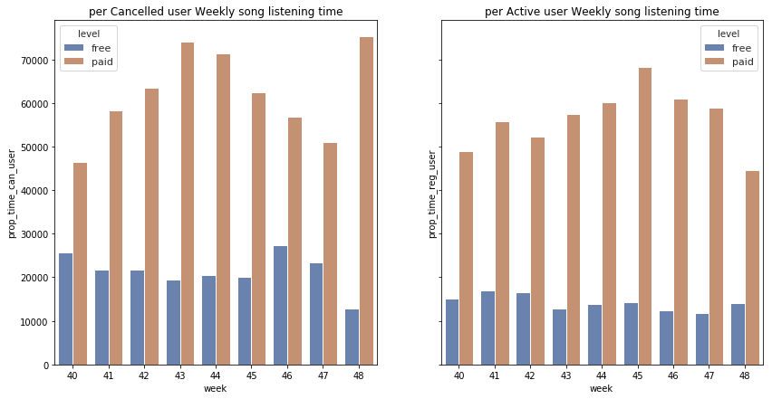

```python
# Plot the df_listen figures as graph
f, axes = plt.subplots(1, 2, figsize=(14, 7), sharey=True)

sbn.set(style="white", palette="muted", color_codes=True)

ax1 = sbn.barplot(data=df_listen, x='week', y='prop_time_can_user', hue='level', ax=axes[0], saturation=0.50);
ax1.set_title("per Cancelled user Weekly song listening time")

ax2 = sbn.barplot(data=df_listen, x='week', y='prop_time_reg_user', hue='level', ax=axes[1], saturation=0.50);
ax2.set_title("per Active user Weekly song listening time")

plt.show();
```

The paid user seems to spend more time as expected. But it is surprising to see per cancelled users send more time listening to song in a week than per registered user especially in the last week.

###### Let us now considered number of sessions per week for cancelled and registered user.

```python
df_c_s = spark.sql('''
-- cancelled user
SELECT weekofyear(from_unixtime(a.ts/1000, 'yyyy-MM-dd')) as week
      ,a.level
      ,count(distinct a.sessionId) as Can_user_sessions
      ,count(distinct(a.userId)) as user_C
  FROM log_table a
      ,log_table b
 WHERE a.userId = b.userId
   AND a.page = 'NextSong'
   AND b.page = 'Cancel'
 GROUP by week
         ,a.level
 ORDER by week
         ,a.level
''').toPandas()
```

```python
df_r_s = spark.sql('''
-- Registered users
SELECT weekofyear(from_unixtime(a.ts/1000, 'yyyy-MM-dd')) as week
      ,a.level
      ,count(distinct a.sessionId) as Reg_user_sessions
      ,count(distinct a.userId) as user_R
  FROM log_table a
 WHERE a.page = 'NextSong'
   AND a.userId not in
       ( SELECT userId from log_table b
          WHERE page = 'Cancel'
            AND a.userId = b.userId
       )
 GROUP by week
      ,a.level
 ORDER by week
      ,a.level
''').toPandas()
```

```python
# Caputure the result of both the queries as pandas dataframe
df_session = pd.merge(df_c_s, df_r_s, on=['week', 'level'])
```

```python
df_session['prop_time_can_user'] = df_session['Can_user_sessions'] / df_session['user_C']
df_session['prop_time_reg_user'] = df_session['Reg_user_sessions'] / df_session['user_R']
```

```python
df_session.style.hide_index()
```

| week | level | Can_user_sessions | user_C | Reg_user_sessions | user_R | prop_time_can_user | prop_time_reg_user |
| --- | --- | --- | --- | --- | --- | --- | --- |
| 40 | free | 185 | 66 | 342 | 191 | 2.80303 | 1.79058 |
| 40 | paid | 86 | 38 | 188 | 90 | 2.26316 | 2.08889 |
| 41 | free | 136 | 51 | 306 | 155 | 2.66667 | 1.97419 |
| 41 | paid | 72 | 35 | 287 | 118 | 2.05714 | 2.4322 |
| 42 | free | 109 | 40 | 272 | 132 | 2.725 | 2.06061 |
| 42 | paid | 83 | 31 | 306 | 136 | 2.67742 | 2.25 |
| 43 | free | 58 | 24 | 228 | 121 | 2.41667 | 1.8843 |
| 43 | paid | 113 | 39 | 326 | 133 | 2.89744 | 2.45113 |
| 44 | free | 35 | 14 | 224 | 122 | 2.5 | 1.83607 |
| 44 | paid | 110 | 40 | 380 | 147 | 2.75 | 2.58503 |
| 45 | free | 38 | 15 | 184 | 95 | 2.53333 | 1.93684 |
| 45 | paid | 86 | 36 | 417 | 156 | 2.38889 | 2.67308 |
| 46 | free | 23 | 9 | 156 | 88 | 2.55556 | 1.77273 |
| 46 | paid | 52 | 21 | 418 | 161 | 2.47619 | 2.59627 |
| 47 | free | 13 | 4 | 136 | 85 | 3.25 | 1.6 |
| 47 | paid | 24 | 11 | 366 | 159 | 2.18182 | 2.30189 |
| 48 | free | 7 | 3 | 142 | 82 | 2.33333 | 1.73171 |
| 48 | paid | 15 | 5 | 340 | 149 | 3 | 2.28188 |

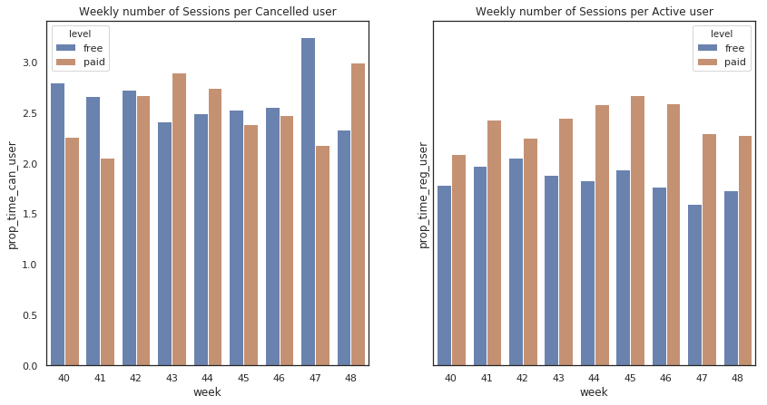

```python
# Plot the df_listen figures as graph
f, axes = plt.subplots(1, 2, figsize=(14, 7), sharey=True)

sbn.set(style="white", palette="muted", color_codes=True)

ax1 = sbn.barplot(data=df_session, x='week', y='prop_time_can_user', hue='level', ax=axes[0], saturation=0.50);
ax1.set_title("Weekly number of Sessions per Cancelled user")

ax2 = sbn.barplot(data=df_session, x='week', y='prop_time_reg_user', hue='level', ax=axes[1], saturation=0.50);
ax2.set_title("Weekly number of Sessions per Active user")

plt.show();
```

The paid and registered user seems to have more number of session per week as compared to registered and free user as the graph 2. But tread is not very eveident with cancelled users.

###### Let us now see number of items per week which indicates the navigation the users

```python
df_items_c = spark.sql('''
-- cancelled user
SELECT weekofyear(from_unixtime(a.ts/1000, 'yyyy-MM-dd')) as week
      ,a.level
      ,count(a.itemInSession) as Can_user_item
      ,count(distinct a.userId) as user_C
  FROM log_table a
      ,log_table b
 WHERE a.userId = b.userId
   AND b.page = 'Cancel'
 GROUP by week
        ,a.level
 ORDER by week
        ,a.level
''').toPandas()
```

```python
df_items_c.head(15).style.hide_index()
```

| week | level | Can_user_item | user_C |
| --- | --- | --- | --- |
| 40 | free | 9218 | 67 |
| 40 | paid | 8568 | 39 |
| 41 | free | 5935 | 51 |
| 41 | paid | 9679 | 35 |
| 42 | free | 4625 | 40 |
| 42 | paid | 9327 | 31 |
| 43 | free | 2490 | 24 |
| 43 | paid | 13789 | 39 |
| 44 | free | 1542 | 14 |
| 44 | paid | 13748 | 40 |
| 45 | free | 1643 | 15 |
| 45 | paid | 10845 | 36 |
| 46 | free | 1342 | 9 |
| 46 | paid | 5708 | 21 |
| 47 | free | 479 | 4 |

```python
df_items_r = spark.sql('''
-- active users
SELECT weekofyear(from_unixtime(a.ts/1000, 'yyyy-MM-dd')) as week
      ,a.level
      ,count(a.itemInSession) as Reg_user_items
      ,count(distinct a.userId) as user_R
  FROM log_table a \
 WHERE a.userId not in
       ( SELECT userId
           FROM log_table b
          WHERE page = 'Cancel'
            AND a.userId = b.userId
       )
 GROUP by week
         ,a.level
 ORDER by week
         ,a.level
''').toPandas()
```

```python
df_items_r.head(15).style.hide_index()
```

| week | level | Reg_user_items | user_R |
| --- | --- | --- | --- |
| 40 | free | 16332 | 194 |
| 40 | paid | 22032 | 93 |
| 41 | free | 14736 | 158 |
| 41 | paid | 32730 | 121 |
| 42 | free | 12188 | 136 |
| 42 | paid | 35408 | 138 |
| 43 | free | 8798 | 122 |
| 43 | paid | 38041 | 136 |
| 44 | free | 9643 | 127 |
| 44 | paid | 44090 | 151 |
| 45 | free | 7594 | 98 |
| 45 | paid | 52544 | 157 |
| 46 | free | 6204 | 91 |
| 46 | paid | 48359 | 164 |
| 47 | free | 5660 | 90 |

```python
# Caputure the result of both the queries as pandas dataframe
df_items = pd.merge(df_c_s, df_r_s, on=['week', 'level'])
df_items['prop_items_can_user'] = df_items['Can_user_sessions'] / df_items['user_C']
df_items['prop_items_reg_user'] = df_items['Reg_user_sessions'] / df_items['user_R']
df_items.head(10).style.hide_index()
```

| week | level | Can_user_sessions | user_C | Reg_user_sessions | user_R | prop_items_can_user | prop_items_reg_user |
| --- | --- | --- | --- | --- | --- | --- | --- |
| 40 | free | 185 | 66 | 342 | 191 | 2.80303 | 1.79058 |
| 40 | paid | 86 | 38 | 188 | 90 | 2.26316 | 2.08889 |
| 41 | free | 136 | 51 | 306 | 155 | 2.66667 | 1.97419 |
| 41 | paid | 72 | 35 | 287 | 118 | 2.05714 | 2.4322 |
| 42 | free | 109 | 40 | 272 | 132 | 2.725 | 2.06061 |
| 42 | paid | 83 | 31 | 306 | 136 | 2.67742 | 2.25 |
| 43 | free | 58 | 24 | 228 | 121 | 2.41667 | 1.8843 |
| 43 | paid | 113 | 39 | 326 | 133 | 2.89744 | 2.45113 |
| 44 | free | 35 | 14 | 224 | 122 | 2.5 | 1.83607 |
| 44 | paid | 110 | 40 | 380 | 147 | 2.75 | 2.58503 |

[figure not shown]

```python
# Plot the df_items figures as graph
f, axes = plt.subplots(1, 2, figsize=(14, 7), sharey=True)

sbn.set(style="white", palette="muted", color_codes=True)

ax1 = sbn.barplot(data=df_items, x='week', y='prop_items_can_user', hue='level', ax=axes[0], saturation=0.50);
ax1.set_title("Weekly Items navigated per Cancelled user")

ax2 = sbn.barplot(data=df_items, x='week', y='prop_items_reg_user', hue='level', ax=axes[1], saturation=0.50);
ax2.set_title("Weekly Items navigated per Active user")

plt.show();
```

###### Now let us consider number of Thumbu up, Thumbs down, Add friend events

```python
# SQL to get the count of thumbs up per cancelled user by week

df_thumbs_up_c = spark.sql('''
-- cancelled user
SELECT weekofyear(from_unixtime(a.ts/1000, 'yyyy-MM-dd')) as week
      ,a.level
      ,count(a.itemInSession) as Can_user_event
      ,count(distinct(a.userId)) as user_C
  FROM log_table a
      ,log_table b
 WHERE a.userId = b.userId
   AND a.page = 'Thumbs Up'
   AND b.page = 'Cancel'
 GROUP by
       week
      ,a.level
 ORDER by
       week
      ,a.level
''').toPandas()
```

```python
# SQL to get the count of thumbs down per cancelled user by week

df_thumbs_down_c = spark.sql('''
-- cancelled user
SELECT weekofyear(from_unixtime(a.ts/1000, 'yyyy-MM-dd')) as week
      ,a.level
      ,count(a.itemInSession) as Can_user_event
      ,count(distinct(a.userId)) as user_C
  FROM log_table a
      ,log_table b
 WHERE a.userId = b.userId
   AND a.page = 'Thumbs Down'
   AND b.page = 'Cancel'
 GROUP by
       week
      ,a.level
 ORDER by
       week
      ,a.level
''').toPandas()
```

```python
# SQL to get the count of add friend event per cancelled user by week

df_add_friend_c = spark.sql('''
-- cancelled user
SELECT weekofyear(from_unixtime(a.ts/1000, 'yyyy-MM-dd')) as week
      ,a.level
      ,count(a.itemInSession) as Can_user_event
      ,count(distinct(a.userId)) as user_C
  FROM log_table a
      ,log_table b
 WHERE a.userId = b.userId
   AND a.page = 'Add Friend'
   AND b.page = 'Cancel'
 GROUP by
       week
      ,a.level
 ORDER by
       week
      ,a.level
''').toPandas()
```

```python
# SQL to get the count of thumbs up event per active user by week

df_thumbs_up_r = spark.sql('''
-- active users
SELECT weekofyear(from_unixtime(a.ts/1000, 'yyyy-MM-dd')) as week
      ,a.level
      ,a.page
      ,count(a.itemInSession) as active_user_event
      ,count(distinct(a.userId)) as user_R
  FROM log_table a
 WHERE a.page = 'Thumbs Up'
   AND a.userId not in
       ( SELECT userId from log_table b
          WHERE page = 'Cancel'
            AND a.userId = b.userId
       )
 GROUP by week
         ,a.level
         ,a.page
 ORDER by week
         ,a.level
         ,a.page
''').toPandas()
```

```python
# SQL to get the count of thumbs down event per active user by week

df_thumbs_down_r = spark.sql('''
-- active users
SELECT weekofyear(from_unixtime(a.ts/1000, 'yyyy-MM-dd')) as week
      ,a.level
      ,a.page
      ,count(a.itemInSession) as active_user_event
      ,count(distinct(a.userId)) as user_R
  FROM log_table a
 WHERE a.page = 'Thumbs Down'
   AND a.userId not in
       ( SELECT userId from log_table b
          WHERE page = 'Cancel'
            AND a.userId = b.userId
       )
 GROUP BY week
         ,a.level
         ,a.page
 ORDER BY week
         ,a.level
         ,a.page
''').toPandas()
```

```python
# SQL to get the count of add friend event per active user by week

df_add_friend_r = spark.sql('''
-- active users
SELECT weekofyear(from_unixtime(a.ts/1000, 'yyyy-MM-dd')) as week
      ,a.level
      ,a.page
      ,count(a.itemInSession) as active_user_event
      ,count(distinct(a.userId)) as user_R
  FROM log_table a
 WHERE a.page = 'Add Friend'
   AND a.userId not in
       ( SELECT userId from log_table b
          WHERE page = 'Cancel'
            AND a.userId = b.userId
       )
 GROUP by week
         ,a.level
         ,a.page
ORDER by week
         ,a.level
         ,a.page
''').toPandas()
```

```python
# Calcuate per user events cancelled user
df_thumbs_up_c['event_per_user'] = df_thumbs_up_c['Can_user_event'] / df_thumbs_up_c['user_C']
df_thumbs_down_c['event_per_user'] = df_thumbs_down_c['Can_user_event'] / df_thumbs_down_c['user_C']
df_add_friend_c['event_per_user'] = df_add_friend_c['Can_user_event'] / df_add_friend_c['user_C']

# Calcuate per user events active user
df_thumbs_up_r['event_per_user'] = df_thumbs_up_r['active_user_event'] / df_thumbs_up_r['user_R']
df_thumbs_down_r['event_per_user'] = df_thumbs_down_r['active_user_event'] / df_thumbs_down_r['user_R']
df_add_friend_r['event_per_user'] = df_add_friend_r['active_user_event'] / df_add_friend_r['user_R']
```

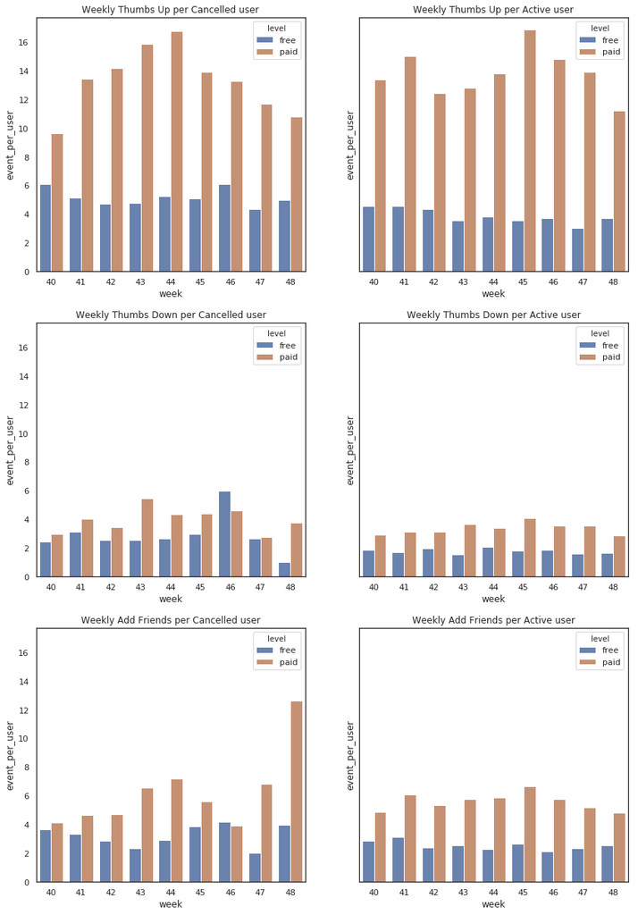

```python
# Plot the events figures as graph
f, axes = plt.subplots(3, 2, figsize=(14, 21), sharey=True)

sbn.set(style="white", palette="muted", color_codes=True)


list_dfs = [[df_thumbs_up_c, df_thumbs_up_r],
            [df_thumbs_down_c, df_thumbs_down_r],
            [df_add_friend_c, df_add_friend_r],
           ]

titles = [["Weekly Thumbs Up per Cancelled user", "Weekly Thumbs Up per Active user" ],
          ["Weekly Thumbs Down per Cancelled user", "Weekly Thumbs Down per Active user" ],
          ["Weekly Add Friends per Cancelled user", "Weekly Add Friends per Active user" ],
         ]

for i,a in enumerate(axes):
    for j,ax in enumerate(a):
        ax = sbn.barplot(data=list_dfs[i][j], x='week', y='event_per_user', hue='level', ax=axes[i,j], saturation=0.50);
        ax.set_title(titles[i][j]);

plt.show();
```

The above graphs shows Cancelled users and Active user are having faily same level of thumbs up and thumbs downs. cancel users have relatively added more friends than active users. This could be they are more enagaged with friends :)

###### Let us check the roll advert frequency for Active and cancelled users

```python
# SQL to get the count of roll advert per cancelled user by week

df_roll_advert_c = spark.sql('''
-- cancelled user
SELECT weekofyear(from_unixtime(a.ts/1000, 'yyyy-MM-dd')) as week
      ,a.level
      ,count(a.itemInSession) as Can_user_event
      ,count(distinct(a.userId)) as user_C
  FROM log_table a
      ,log_table b
 WHERE a.userId = b.userId
   AND a.page = 'Roll Advert'
   AND b.page = 'Cancel'
 GROUP by
       week
      ,a.level
 ORDER by
       week
      ,a.level
''').toPandas()
```

```python
df_roll_advert_c.head(10).style.hide_index()
```

| week | level | Can_user_event | user_C |
| --- | --- | --- | --- |
| 40 | free | 679 | 61 |
| 40 | paid | 22 | 14 |
| 41 | free | 459 | 46 |
| 41 | paid | 15 | 6 |
| 42 | free | 346 | 37 |
| 42 | paid | 13 | 8 |
| 43 | free | 185 | 22 |
| 43 | paid | 21 | 13 |
| 44 | free | 107 | 14 |
| 44 | paid | 25 | 18 |

```python
# SQL to get the count of advert event per active user by week

df_roll_advert_r = spark.sql('''
-- active users
SELECT weekofyear(from_unixtime(a.ts/1000, 'yyyy-MM-dd')) as week
      ,a.level
      ,a.page
      ,count(a.itemInSession) as active_user_event
      ,count(distinct(a.userId)) as user_R
  FROM log_table a
 WHERE a.page = 'Roll Advert'
   AND a.userId not in
       ( SELECT userId from log_table b
          WHERE page = 'Cancel'
            AND a.userId = b.userId
       )
 GROUP BY week
         ,a.level
         ,a.page
ORDER BY week
         ,a.level
         ,a.page
''').toPandas()
```

```python
df_roll_advert_r.head(10).style.hide_index()
```

| week | level | page | active_user_event | user_R |
| --- | --- | --- | --- | --- |
| 40 | free | Roll Advert | 924 | 151 |
| 40 | paid | Roll Advert | 18 | 18 |
| 41 | free | Roll Advert | 876 | 134 |
| 41 | paid | Roll Advert | 25 | 20 |
| 42 | free | Roll Advert | 690 | 114 |
| 42 | paid | Roll Advert | 37 | 26 |
| 43 | free | Roll Advert | 519 | 97 |
| 43 | paid | Roll Advert | 30 | 23 |
| 44 | free | Roll Advert | 664 | 102 |
| 44 | paid | Roll Advert | 41 | 34 |

```python
# Calcuate per user events
df_roll_advert_c['event_per_user'] = df_roll_advert_c['Can_user_event'] / df_roll_advert_c['user_C']
df_roll_advert_r['event_per_user'] = df_roll_advert_r['active_user_event'] / df_roll_advert_r['user_R']
```

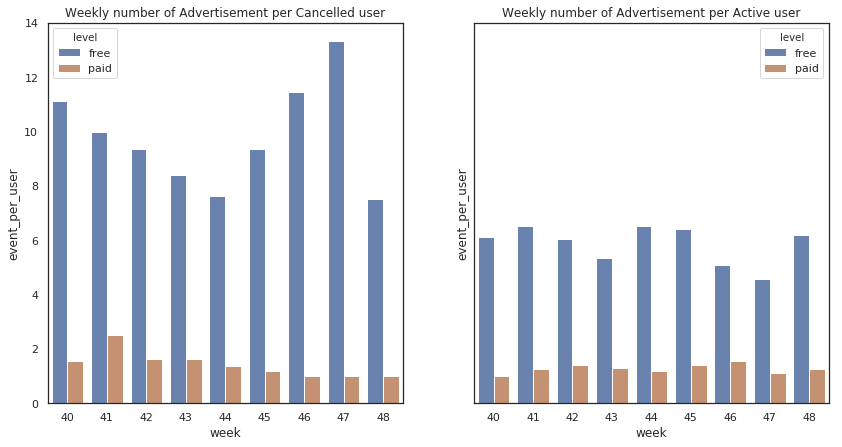

```python
# Plot the roll advert data as graph
f, axes = plt.subplots(1, 2, figsize=(14, 7), sharey=True)

sbn.set(style="white", palette="muted", color_codes=True)

ax1 = sbn.barplot(data=df_roll_advert_c, x='week', y='event_per_user', hue='level', ax=axes[0], saturation=0.50);
ax1.set_title("Weekly number of Advertisement per Cancelled user")

ax2 = sbn.barplot(data=df_roll_advert_r, x='week', y='event_per_user', hue='level', ax=axes[1], saturation=0.50);
ax2.set_title("Weekly number of Advertisement per Active user")

plt.show();
```

Looks like the `cancelled` users have got more adverts that `active` users. THis is possible because of more time they have spent and overall more songs they have listen the remaining active users.

###### Let us check the Help page ; Save settting page visits for Active and cancelled users

```python
# SQL to get the count of help per cancelled user by week

df_help_c = spark.sql('''
-- cancelled user
SELECT weekofyear(from_unixtime(a.ts/1000, 'yyyy-MM-dd')) as week
      ,a.level
      ,count(a.itemInSession) as Can_user_event
      ,count(distinct(a.userId)) as user_C
  FROM log_table a
      ,log_table b
 WHERE a.userId = b.userId
   AND a.page = 'Help'
   AND b.page = 'Cancel'
 GROUP by
       week
      ,a.level
 ORDER by
       week
      ,a.level
''').toPandas()
```

```python
df_help_c.head(10).style.hide_index()
```

| week | level | Can_user_event | user_C |
| --- | --- | --- | --- |
| 40 | free | 46 | 26 |
| 40 | paid | 37 | 22 |
| 41 | free | 29 | 18 |
| 41 | paid | 44 | 21 |
| 42 | free | 21 | 16 |
| 42 | paid | 51 | 19 |
| 43 | free | 9 | 7 |
| 43 | paid | 73 | 24 |
| 44 | free | 9 | 6 |
| 44 | paid | 66 | 26 |

```python
# SQL to get the count of Help page event per active user by week

df_help_r = spark.sql('''
-- active users
SELECT weekofyear(from_unixtime(a.ts/1000, 'yyyy-MM-dd')) as week
      ,a.level
      ,a.page
      ,count(a.itemInSession) as active_user_event
      ,count(distinct(a.userId)) as user_R
  FROM log_table a
 WHERE a.page = 'Help'
   AND a.userId not in
       ( SELECT userId from log_table b
          WHERE page = 'Cancel'
            AND a.userId = b.userId
       )
 GROUP BY week
         ,a.level
         ,a.page
 ORDER BY week
         ,a.level
         ,a.page
''').toPandas()
```

```python
df_help_r.head(10).style.hide_index()
```

| week | level | page | active_user_event | user_R |
| --- | --- | --- | --- | --- |
| 40 | free | Help | 142 | 56 |
| 40 | paid | Help | 113 | 45 |
| 41 | free | Help | 116 | 59 |
| 41 | paid | Help | 170 | 64 |
| 42 | free | Help | 63 | 33 |
| 42 | paid | Help | 195 | 78 |
| 43 | free | Help | 51 | 29 |
| 43 | paid | Help | 252 | 81 |
| 44 | free | Help | 72 | 32 |
| 44 | paid | Help | 302 | 92 |

```python
# SQL to get the count of help per cancelled user by week

df_settings_c = spark.sql('''
-- cancelled user
SELECT weekofyear(from_unixtime(a.ts/1000, 'yyyy-MM-dd')) as week
      ,a.level
      ,count(a.itemInSession) as Can_user_event
      ,count(distinct(a.userId)) as user_C
  FROM log_table a
      ,log_table b
 WHERE a.userId = b.userId
   AND a.page = 'Save Settings'
   AND b.page = 'Cancel'
 GROUP by
       week
      ,a.level
 ORDER by
       week
      ,a.level
''').toPandas()
```

```python
df_settings_c.head(10).style.hide_index()
```

| week | level | Can_user_event | user_C |
| --- | --- | --- | --- |
| 40 | free | 11 | 11 |
| 40 | paid | 15 | 10 |
| 41 | free | 11 | 10 |
| 41 | paid | 8 | 7 |
| 42 | free | 6 | 4 |
| 42 | paid | 5 | 5 |
| 43 | free | 3 | 3 |
| 43 | paid | 12 | 10 |
| 44 | free | 1 | 1 |
| 44 | paid | 13 | 10 |

```python
# SQL to get the count of Help page event per active user by week

df_settings_r = spark.sql('''
-- active users
SELECT weekofyear(from_unixtime(a.ts/1000, 'yyyy-MM-dd')) as week
      ,a.level
      ,a.page
      ,count(a.itemInSession) as active_user_event
      ,count(distinct(a.userId)) as user_R
  FROM log_table a
 WHERE a.page = 'Save Settings'
   AND a.userId not in
       ( SELECT userId from log_table b
          WHERE page = 'Cancel'
            AND a.userId = b.userId
       )
 GROUP BY week
         ,a.level
         ,a.page
 ORDER BY week
         ,a.level
         ,a.page
''').toPandas()
```

```python
df_settings_r.head(10).style.hide_index()
```

| week | level | page | active_user_event | user_R |
| --- | --- | --- | --- | --- |
| 40 | free | Save Settings | 20 | 18 |
| 40 | paid | Save Settings | 18 | 14 |
| 41 | free | Save Settings | 21 | 17 |
| 41 | paid | Save Settings | 33 | 25 |
| 42 | free | Save Settings | 18 | 16 |
| 42 | paid | Save Settings | 35 | 27 |
| 43 | free | Save Settings | 14 | 12 |
| 43 | paid | Save Settings | 48 | 39 |
| 44 | free | Save Settings | 12 | 9 |
| 44 | paid | Save Settings | 48 | 37 |

```python
# Calcuate per user events for help page visit
df_help_c['event_per_user'] = df_help_c['Can_user_event'] / df_help_c['user_C']
df_help_r['event_per_user'] = df_help_r['active_user_event'] / df_help_r['user_R']

# Calcuate per user events for save settings page visit
df_settings_c['event_per_user'] = df_settings_c['Can_user_event'] / df_settings_c['user_C']
df_settings_r['event_per_user'] = df_settings_r['active_user_event'] / df_settings_r['user_R']
```

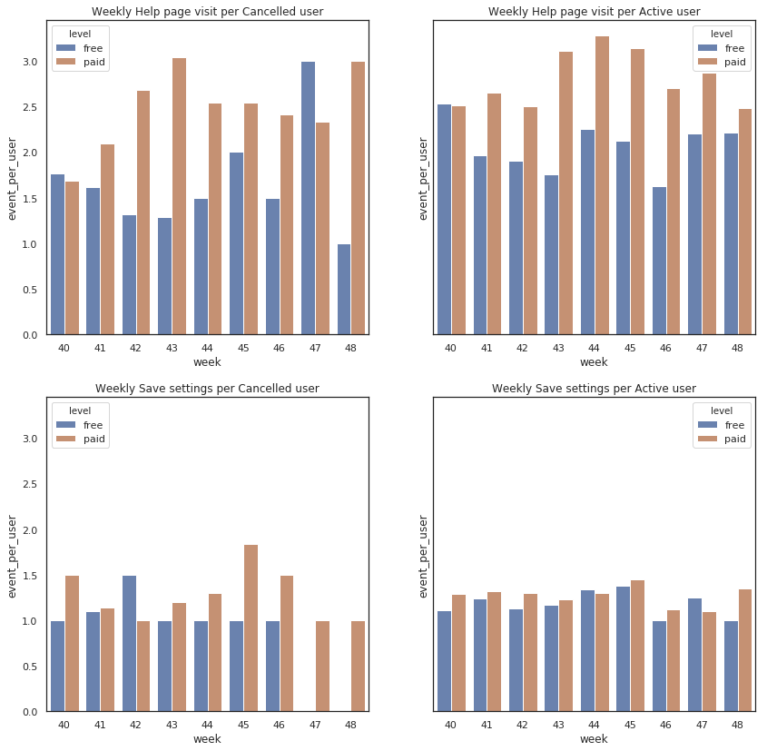

```python
# Plot the events figures as graph
f, axes = plt.subplots(2, 2, figsize=(14, 14), sharey=True)

sbn.set(style="white", palette="muted", color_codes=True)


list_dfs = [[df_help_c, df_help_r],
            [df_settings_c, df_settings_r],
           ]

titles = [["Weekly Help page visit per Cancelled user", "Weekly Help page visit per Active user" ],
          ["Weekly Save settings per Cancelled user", "Weekly Save settings per Active user" ],
         ]

for i,a in enumerate(axes):
    for j,ax in enumerate(a):
        ax = sbn.barplot(data=list_dfs[i][j], x='week', y='event_per_user', hue='level', ax=axes[i,j], saturation=0.50);
        ax.set_title(titles[i][j]);

plt.show();
```

Clearly the tread show `Active` users both `free` or `paid used Help pages more often`cancelled`users.`Save setting`seems to be of almost same frequency with`cancelled`and`active` user

###### Let us now consider how the individual song have contributed to Cancel, Downgrade and Upgrade.

```python
df_song_c = spark.sql(
'''
SELECT a.song, count(distinct(a.userId)) as can_user
  FROM log_table a
      ,log_table b
WHERE a.userId = b.userId
  AND a.page = 'NextSong'
  AND b.page = 'Cancel'
GROUP by a.song
ORDER by 2 desc
LIMIT 50
''').toPandas()
```

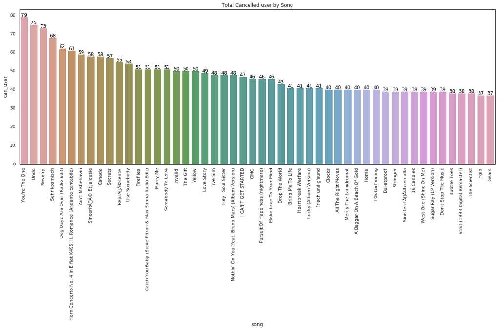

```python
# Plot the df_song_c figures a graph
f, axes = plt.subplots(1, 1, figsize=(21, 7))

sbn.set(style="white", palette="muted", color_codes=True)

ax1 = sbn.barplot(data=df_song_c, x='song', y='can_user', saturation=0.50);
ax1.set_title("Total Cancelled user by Song")

for i, row in df_song_c.iterrows():
   ax1.text(row.name, row.can_user, row.can_user, color='black', ha='center')

plt.xticks(rotation = 90)
plt.show();
```

```python
# Find the song where most User downgraded

df_song_d = spark.sql( '''
SELECT a.song, count(distinct(a.userId)) as downgrade_user
  FROM log_table a
      ,log_table b
WHERE a.userId = b.userId
  AND a.page = 'NextSong'
  AND b.page = 'Downgrade'
GROUP by a.song
ORDER by 2 desc
LIMIT 50
''').toPandas()
```

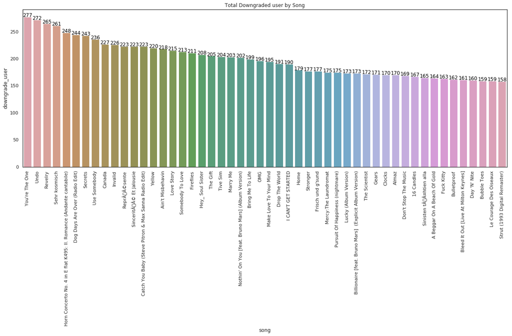

```python
# Plot the df_song_d figures a graph
f, axes = plt.subplots(1, 1, figsize=(21, 7))

sbn.set(style="white", palette="muted", color_codes=True)

ax1 = sbn.barplot(data=df_song_d, x='song', y='downgrade_user', saturation=0.50);
ax1.set_title("Total Downgraded user by Song")

for i, row in df_song_d.iterrows():
   ax1.text(row.name, row.downgrade_user, row.downgrade_user, color='black', ha='center')

plt.xticks(rotation = 90)
plt.show();
```

```python
df_song_u = spark.sql( '''
SELECT a.song, count(distinct(a.userId)) as upgrade_user
  FROM log_table a
      ,log_table b
WHERE a.userId = b.userId
  AND a.page = 'NextSong'
  AND b.page = 'Upgrade'
GROUP by a.song
ORDER by 2 desc
LIMIT 50
''').toPandas()
```

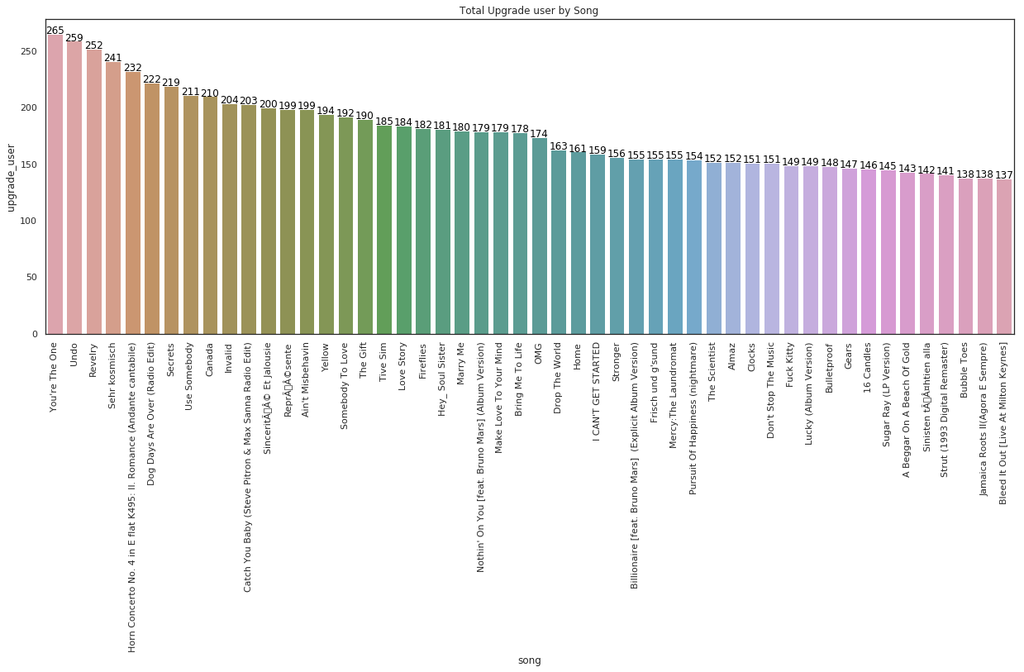

```python
# Plot the df_song_c figures a graph
f, axes = plt.subplots(1, 1, figsize=(21, 7))

sbn.set(style="white", palette="muted", color_codes=True)

ax1 = sbn.barplot(data=df_song_u, x='song', y='upgrade_user', saturation=0.50);
ax1.set_title("Total Upgrade user by Song")

for i, row in df_song_u.iterrows():
   ax1.text(row.name, row.upgrade_user, row.upgrade_user, color='black', ha='center')

plt.xticks(rotation = 90)
plt.show();
```

We coud observe that first 4 song are same in all the 3 categories `Cancel`, `Upgrade` and `downgrade`. That is possible due to they could be most popular song for all users. Never the less different user have have listenend to diffent set of songs so we will have unique score for all the songs listen by the user.

##### Let us analyse the how users `Browser` and `OS` of the device used contribute to `Cancel`, `Downgrade` and `Upgrade`

```python
%%sparksql -l 100
SELECT DISTINCT(userAgent), page
  FROM log_t
 WHERE userAgent is NULL
```

| userAgent | page |
| --- | --- |
| null | Home |
| null | About |
| null | Submit Registration |
| null | Login |
| null | Register |
| null | Help |
| null | Error |

We could see that `userAgent` value is null for some of the pages, if we use the null values we will end up with null OS and browsers for some of the records. Let us check if every `userID` has atleast not null `userAgent`

```python
%%sparksql -l 100
SELECT userID, userAgent
  FROM log_t
 WHERE userAgent is NULL
 GROUP by userID
         ,userAgent
```

| userID | userAgent |
| --- | --- |
|  | null |

There results there is no user without a userAgent. Let is get `userAgent` of every `userId` and use it to derive OS and browser of the user.

```python
df_userAgent = df.filter('userAgent is not NULL')     \
                 .groupBy('userId','userAgent')       \
                 .agg(col('userId'),col('userAgent')) \
                 .select('userID','userAgent')        \
                 .collect()
```

```python
df_userAgent = spark.createDataFrame(df_userAgent)
```

```python
df_userAgent.show(2)
```

```
+------+--------------------+
|userID|           userAgent|
+------+--------------------+
|   188|"Mozilla/5.0 (Mac...|
|200021|Mozilla/5.0 (Maci...|
+------+--------------------+
only showing top 2 rows
```

##### Define functions for extracing `OS` and `Browser` from the `userAgent` value

```python
def findOS(s):
    '''
    Return the operating system string from the passed the string
    '''
    re1 = re.compile("\\((.*?)\\)")
    re_win = re.compile('Windows')
    re_mac = re.compile('Macintosh')
    re_comp = re.compile('compatible')
    re_X11  = re.compile('X11')
    re_ipad  = re.compile('iPad')
    re_iphone  = re.compile('iPhone')

    for os in re1.findall(s):
         if re_mac.search(os):
             return os.split(';')[1].lstrip()
         elif re_ipad.search(os):
             return os.split(';')[1].lstrip()
         elif re_iphone.search(os):
             return os.split(';')[1].lstrip()
         elif re_comp.search(os):
            return os.split(';')[2].lstrip()
         elif re_win.search(os):
             return os.split(';')[0].lstrip()
         elif re_X11.search(os):
             return 'Ubuntu'
```

```python
def findBrowser(s):
    '''
    Return the browser string from the passed the string
    '''
    if s != None:
         return s.split(' ')[-1].split(')')[0]
    else:
         return ' '
```

```python
find_OS = udf(lambda x: findOS(str(x)), StringType())
```

```python
find_Browser = udf(lambda x: findBrowser(str(x)), StringType())
```

```python
#Create OS_ver and Browser_ver as new columns
df_userAgent = spark.createDataFrame(df_userAgent.withColumn('OS_Ver',find_OS('userAgent')) \
                                                 .withColumn('Browser_Ver', find_Browser('userAgent')) \
                                                 .collect() \
                                    )
```

```python
df_userAgent.select('userId', 'OS_ver', 'Browser_Ver').show(10,False)
```

```
+------+---------------------------------+----------------+
|userId|OS_ver                           |Browser_Ver     |
+------+---------------------------------+----------------+
|188   |Intel Mac OS X 10_9_4            |Safari/537.77.4"|
|200021|Intel Mac OS X 10.7              |Firefox/31.0    |
|100010|CPU iPhone OS 7_1_2 like Mac OS X|Safari/9537.53" |
|300049|Windows NT 6.1                   |Safari/537.36"  |
|200026|Windows NT 6.1                   |Trident/5.0     |
|300039|Intel Mac OS X 10_9_4            |Safari/537.36"  |
|7     |Windows NT 6.1                   |Firefox/31.0    |
|117   |Windows NT 6.1                   |Safari/537.36"  |
|199   |Intel Mac OS X 10_9_4            |Safari/537.36"  |
|200029|Intel Mac OS X 10_9_4            |Safari/537.36"  |
+------+---------------------------------+----------------+
only showing top 10 rows
```

Let us extract the OS and Browser values from `OS_ver` and `Browser_ver` columns

```python
def findOSMain(s):
    '''
    Return the operating system string from the passed the string
    '''
    re_win = re.compile('Windows')
    re_mac = re.compile('Mac OS')
    re_ubuntu = re.compile('Ubuntu')

    if re_mac.search(s):
        return 'Macintosh'
    elif re_win.search(s):
        return 'Windows'
    elif re_ubuntu.search(s):
        return 'Ubuntu'
    else:
        return s
```

```python
def findBrowserMain(s):
    '''
    Return the browser string from the passed the string
    '''
    re_firefox = re.compile('Firefox')
    re_Safari  = re.compile('Safari')
    re_Gecko   = re.compile('Gecko')
    re_Trident = re.compile('Trident')

    if re_firefox.search(s):
        return 'Firefox'
    elif re_Safari.search(s):
        return 'Safari'
    elif re_Gecko.search(s):
        return 'Firefox'
    elif re_Trident.search(s):
        return 'Trident'
    else:
         return s
```

```python
find_Main_OS = udf(lambda x: findOSMain(str(x)), StringType())
```

```python
find_Main_Browser = udf(lambda x: findBrowserMain(str(x)), StringType())
```

```python
#Create OS and Browser as new columns
df_userAgent = spark.createDataFrame(df_userAgent.withColumn('OS',find_Main_OS('OS_ver')) \
                                                 .withColumn('Browser', find_Main_Browser('Browser_Ver')) \
                                                 .collect() \
                                    )
```

```python
# Add browser OS cominations as columns to df_userAgent
concatOSBrowser = udf(lambda x,y : str(x) + '-' + str(y), StringType())
```

```python
df_userAgent = df_userAgent.withColumn('OSBrowser',concatOSBrowser(col('OS'), col('Browser'))).collect()
```

```python
df_userAgent = spark.createDataFrame(df_userAgent)
```

```python
df_userAgent.select('userId', 'OS', 'OS_ver', 'Browser', 'Browser_Ver', 'OSBrowser').show(10,False)
```

```
+------+---------+---------------------------------+-------+----------------+-----------------+
|userId|OS       |OS_ver                           |Browser|Browser_Ver     |OSBrowser        |
+------+---------+---------------------------------+-------+----------------+-----------------+
|188   |Macintosh|Intel Mac OS X 10_9_4            |Safari |Safari/537.77.4"|Macintosh-Safari |
|200021|Macintosh|Intel Mac OS X 10.7              |Firefox|Firefox/31.0    |Macintosh-Firefox|
|100010|Macintosh|CPU iPhone OS 7_1_2 like Mac OS X|Safari |Safari/9537.53" |Macintosh-Safari |
|300049|Windows  |Windows NT 6.1                   |Safari |Safari/537.36"  |Windows-Safari   |
|200026|Windows  |Windows NT 6.1                   |Trident|Trident/5.0     |Windows-Trident  |
|300039|Macintosh|Intel Mac OS X 10_9_4            |Safari |Safari/537.36"  |Macintosh-Safari |
|7     |Windows  |Windows NT 6.1                   |Firefox|Firefox/31.0    |Windows-Firefox  |
|117   |Windows  |Windows NT 6.1                   |Safari |Safari/537.36"  |Windows-Safari   |
|199   |Macintosh|Intel Mac OS X 10_9_4            |Safari |Safari/537.36"  |Macintosh-Safari |
|200029|Macintosh|Intel Mac OS X 10_9_4            |Safari |Safari/537.36"  |Macintosh-Safari |
+------+---------+---------------------------------+-------+----------------+-----------------+
only showing top 10 rows
```

```python
df_userAgent.createOrReplaceTempView("UserAgent_t")
```

```python
%%sparksql -l 100
SELECT DISTINCT(OS)
  FROM UserAgent_t
 ORDER BY 1
```

| OS |
| --- |
| Macintosh |
| Ubuntu |
| Windows |

```python
%%sparksql -l 100
SELECT DISTINCT(Browser)
  FROM UserAgent_t
 ORDER BY 1
```

| Browser |
| --- |
| Firefox |
| Safari |
| Trident |

```python
%%sparksql -l 100
SELECT DISTINCT(OSBrowser)
  FROM UserAgent_t
 ORDER BY 1
```

| OSBrowser |
| --- |
| Macintosh-Firefox |
| Macintosh-Safari |
| Ubuntu-Firefox |
| Ubuntu-Safari |
| Windows-Firefox |
| Windows-Safari |
| Windows-Trident |

Join the the `df` dataframe and `df_userAgent` dataframe on UserId to merge in OS and Browse fields to main dataframe Recreate `Log_t` table with `OS and Browser` columns for further data Analysis

```python
temp_list = df.alias('m').join(df_userAgent.alias('n'), col('m.userId') == col('n.userId'))  \
             .select([col('m.'+xx) for xx in df.columns] + df_userAgent.columns[2:]) \
             .collect()
```

```python
df = spark.createDataFrame(temp_list)
```

```python
del temp_list
```

```python
df.printSchema()
```

```
root
 |-- artist: string (nullable = true)
 |-- auth: string (nullable = true)
 |-- firstName: string (nullable = true)
 |-- gender: string (nullable = true)
 |-- itemInSession: long (nullable = true)
 |-- lastName: string (nullable = true)
 |-- length: double (nullable = true)
 |-- level: string (nullable = true)
 |-- location: string (nullable = true)
 |-- method: string (nullable = true)
 |-- page: string (nullable = true)
 |-- registration: long (nullable = true)
 |-- sessionId: long (nullable = true)
 |-- song: string (nullable = true)
 |-- status: long (nullable = true)
 |-- ts: long (nullable = true)
 |-- userAgent: string (nullable = true)
 |-- userId: string (nullable = true)
 |-- day: long (nullable = true)
 |-- OS_Ver: string (nullable = true)
 |-- Browser_Ver: string (nullable = true)
 |-- OS: string (nullable = true)
 |-- Browser: string (nullable = true)
 |-- OSBrowser: string (nullable = true)
```

```python
df.createOrReplaceTempView("log_t")
```

##### Let us Analyse the `OS` and `Browser` on cancellation Upgrade and downgrades

###### Cancelled user by OS

```python
%%sparksql -l 100
-- cancelled user by OS
SELECT a.OS  as OS
      ,count(distinct(a.userId)) as can_user
  FROM log_t a
      ,log_t b
WHERE a.userId = b.userId
  AND b.page = 'Cancel'
GROUP by a.OS
ORDER by can_user DESC
LIMIT 50
```

| OS | can_user |
| --- | --- |
| Windows | 48 |
| Macintosh | 46 |
| Ubuntu | 5 |

###### OS user by cancelled user of the OS - this give us more sense of what OS is causing more cancellation

```python
%%sparksql -l 100

select MT.OS
      ,can_user
      ,OS_User
      ,OS_User / can_user as Can_user_per_OS
FROM
    (SELECT a.OS  as OS
          ,count(distinct(a.userId)) as can_user
      FROM log_t a
          ,log_t b
    WHERE a.userId = b.userId
      AND b.page = 'Cancel'
    GROUP by a.OS
    ORDER by can_user DESC) CT

    ,(SELECT a.OS  as OS
          ,count(distinct(a.userId)) as OS_User
      FROM log_t a
     GROUP by a.OS
     ORDER by OS_user DESC) MT

WHERE
    CT.OS = MT.OS
ORDER BY 3 DESC
```

| OS | can_user | OS_User | Can_user_per_OS |
| --- | --- | --- | --- |
| Windows | 48 | 222 | 4.625 |
| Macintosh | 46 | 200 | 4.3478260869565215 |
| Ubuntu | 5 | 26 | 5.2 |

###### Cancelled User by Browser

```python
%%sparksql -l 100
-- cancelled user by Browser
SELECT a.Browser  as Browser
      ,count(distinct(a.userId)) as can_user
  FROM log_t a
      ,log_t b
WHERE a.userId = b.userId
  AND b.page = 'Cancel'
GROUP by a.Browser
ORDER by can_user DESC
LIMIT 50
```

| Browser | can_user |
| --- | --- |
| Safari | 66 |
| Firefox | 31 |
| Trident | 2 |

###### Broswser user by cancelled user of the Browser - this give us more sense of what Browser is causing more cancellation

```python
%%sparksql -l 100
select MT.Browser
      ,can_user
      ,Browser_User
      ,Browser_User / can_user as Can_user_per_Browser
FROM
    (SELECT a.Browser  as Browser
          ,count(distinct(a.userId)) as can_user
      FROM log_t a
          ,log_t b
    WHERE a.userId = b.userId
      AND b.page = 'Cancel'
    GROUP by a.Browser
    ORDER by can_user DESC) CT

    ,(SELECT a.Browser  as Browser
          ,count(distinct(a.userId)) as Browser_User
      FROM log_t a
     GROUP by a.Browser
     ORDER by Browser_User DESC) MT

WHERE
    CT.Browser = MT.Browser
ORDER BY 3 DESC
```

| Browser | can_user | Browser_User | Can_user_per_Browser |
| --- | --- | --- | --- |
| Safari | 66 | 318 | 4.818181818181818 |
| Firefox | 31 | 117 | 3.774193548387097 |
| Trident | 2 | 13 | 6.5 |

###### Cancelled users OS Browser combination

```python
%%sparksql -l 100

SELECT OSBrowser
      ,COUNT(distinct(userId)) as OS_Browser_user
  FROM log_t
 GROUP by OSBrowser
 ORDER by OS_Browser_user DESC
```

| OSBrowser | OS_Browser_user |
| --- | --- |
| Macintosh-Safari | 177 |
| Windows-Safari | 128 |
| Windows-Firefox | 81 |
| Macintosh-Firefox | 23 |
| Ubuntu-Firefox | 13 |
| Ubuntu-Safari | 13 |
| Windows-Trident | 13 |

###### Cancelled user of the OS-Browser comination by number of users with OS-Browser Combination - This give us more sense of what OS-Browser is causing more cancellation

```python
df_OSBrowser_c = spark.sql(
'''
SELECT T1.OSBrowser
      ,OS_Browser_Can_user
      ,OS_Browser_user
      ,OS_Browser_user / OS_Browser_Can_user as Can_user_per_OSBrowser
FROM

    (SELECT MT.OSBrowser as OSBrowser
          ,COUNT(distinct(MT.userId)) as OS_Browser_Can_user
      FROM loG_t MT
          ,log_t CT
     WHERE MT.userId = CT.userId
       AND CT.page = 'Cancel'
     GROUP by
           MT.OSBrowser
     ORDER by
           OS_Browser_Can_user DESC
    )  T1


   ,(SELECT OSBrowser
          ,COUNT(distinct(userId)) as OS_Browser_user
      FROM log_t
     GROUP BY
           OSBrowser
     ORDER by
           OS_Browser_user DESC
    ) T2

WHERE
    T1.OSBrowser = T2.OSBrowser
ORDER BY
    Can_user_per_OSBrowser DESC
''').toPandas()
```

```python
df_OSBrowser_c.style.hide_index()
```

| OSBrowser | OS_Browser_Can_user | OS_Browser_user | Can_user_per_OSBrowser |
| --- | --- | --- | --- |
| Ubuntu-Firefox | 2 | 13 | 6.5 |
| Windows-Trident | 2 | 13 | 6.5 |
| Windows-Safari | 22 | 128 | 5.81818 |
| Macintosh-Firefox | 5 | 23 | 4.6 |
| Ubuntu-Safari | 3 | 13 | 4.33333 |
| Macintosh-Safari | 41 | 177 | 4.31707 |
| Windows-Firefox | 24 | 81 | 3.375 |

We could see a clear tread of cancellation of Browser OS combination

##### Let us observe the Propartion of users for Upgrades

```python
df_OSBrowser_u = spark.sql(
'''
SELECT T1.OSBrowser
      ,OS_Browser_Upgrade_user
      ,OS_Browser_user
      ,OS_Browser_user / OS_Browser_Upgrade_user as Upgrade_user_per_OSBrowser
FROM

    (SELECT MT.OSBrowser as OSBrowser
          ,COUNT(distinct(MT.userId)) as OS_Browser_Upgrade_user
      FROM loG_t MT
          ,log_t CT
     WHERE MT.userId = CT.userId
       AND CT.page = 'Upgrade'
     GROUP by
           MT.OSBrowser
     ORDER by
           OS_Browser_Upgrade_user DESC
    )  T1


   ,(SELECT OSBrowser
          ,COUNT(distinct(userId)) as OS_Browser_user
      FROM log_t
     GROUP BY
           OSBrowser
     ORDER by
           OS_Browser_user DESC
    ) T2

WHERE
    T1.OSBrowser = T2.OSBrowser
ORDER BY
    Upgrade_user_per_OSBrowser DESC
''').toPandas()
```

```python
df_OSBrowser_u.style.hide_index()
```

| OSBrowser | OS_Browser_Upgrade_user | OS_Browser_user | Upgrade_user_per_OSBrowser |
| --- | --- | --- | --- |
| Macintosh-Firefox | 13 | 23 | 1.76923 |
| Windows-Trident | 8 | 13 | 1.625 |
| Windows-Safari | 84 | 128 | 1.52381 |
| Macintosh-Safari | 129 | 177 | 1.37209 |
| Windows-Firefox | 61 | 81 | 1.32787 |
| Ubuntu-Firefox | 10 | 13 | 1.3 |
| Ubuntu-Safari | 10 | 13 | 1.3 |

##### Let us observe the Propartion of users for Downgrade

```python
df_OSBrowser_d = spark.sql(
'''
SELECT T1.OSBrowser
      ,OS_Browser_Downgrade_user
      ,OS_Browser_user
      ,OS_Browser_user / OS_Browser_Downgrade_user as Downgrade_user_per_OSBrowser
FROM

    (SELECT MT.OSBrowser as OSBrowser
          ,COUNT(distinct(MT.userId)) as OS_Browser_Downgrade_user
      FROM loG_t MT
          ,log_t CT
     WHERE MT.userId = CT.userId
       AND CT.page = 'Downgrade'
     GROUP by
           MT.OSBrowser
     ORDER by
           OS_Browser_Downgrade_user DESC
    )  T1


   ,(SELECT OSBrowser
          ,COUNT(distinct(userId)) as OS_Browser_user
      FROM log_t
     GROUP BY
           OSBrowser
     ORDER by
           OS_Browser_user DESC
    ) T2

WHERE
    T1.OSBrowser = T2.OSBrowser
ORDER BY
    Downgrade_user_per_OSBrowser DESC
''').toPandas()
```

```python
df_OSBrowser_d.style.hide_index()
```

| OSBrowser | OS_Browser_Downgrade_user | OS_Browser_user | Downgrade_user_per_OSBrowser |
| --- | --- | --- | --- |
| Windows-Firefox | 52 | 81 | 1.55769 |
| Macintosh-Safari | 116 | 177 | 1.52586 |
| Windows-Safari | 86 | 128 | 1.48837 |
| Ubuntu-Firefox | 9 | 13 | 1.44444 |
| Macintosh-Firefox | 17 | 23 | 1.35294 |
| Windows-Trident | 10 | 13 | 1.3 |
| Ubuntu-Safari | 11 | 13 | 1.18182 |

###### Plot the Cancel, Downgrade, Upgrade per user of OS-Browser combination

```python
df_osbrowser = df_OSBrowser_d[['OSBrowser','Downgrade_user_per_OSBrowser']]         \
                .merge(df_OSBrowser_u[['OSBrowser','Upgrade_user_per_OSBrowser']],  \
                       how='outer',                                                 \
                       suffixes='_d')                                               \
                .merge(df_OSBrowser_c[['OSBrowser','Can_user_per_OSBrowser']],      \
                       how='outer',                                                 \
                       suffixes='_c')                                               \
                .fillna(0)
```

```python
df_osbrowser
```

|  | OSBrowser | Downgrade_user_per_OSBrowser | Upgrade_user_per_OSBrowser | Can_user_per_OSBrowser |
| --- | --- | --- | --- | --- |
| 0 | Windows-Firefox | 1.557692 | 1.327869 | 3.375000 |
| 1 | Macintosh-Safari | 1.525862 | 1.372093 | 4.317073 |
| 2 | Windows-Safari | 1.488372 | 1.523810 | 5.818182 |
| 3 | Ubuntu-Firefox | 1.444444 | 1.300000 | 6.500000 |
| 4 | Macintosh-Firefox | 1.352941 | 1.769231 | 4.600000 |
| 5 | Windows-Trident | 1.300000 | 1.625000 | 6.500000 |
| 6 | Ubuntu-Safari | 1.181818 | 1.300000 | 4.333333 |

```python
df_osbrowser = pd.melt(df_osbrowser,
                       id_vars=['OSBrowser'],
                       value_vars=['Can_user_per_OSBrowser',
                                   'Downgrade_user_per_OSBrowser',
                                   'Upgrade_user_per_OSBrowser'])
```

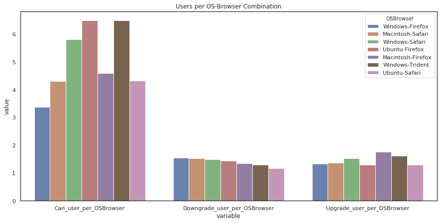

```python
f, axes = plt.subplots(1, 1, figsize=(15, 7))

ax1 = sbn.barplot(data=df_osbrowser,
            x='variable',
            y='value',
            hue='OSBrowser',
            saturation=0.50);

ax1.set_title("Users per OS-Browser Combination")
plt.show();
```

We are ready to extract the features and build model to predict `churn`

# Feature Engineering

Once you've familiarized yourself with the data, build out the features you find promising to train your model on. To work with the full dataset, you can follow the following steps.

- Write a script to extract the necessary features from the smaller subset of data
- Ensure that your script is scalable, using the best practices discussed in Lesson 3
- Try your script on the full data set, debugging your script if necessary

If you are working in the classroom workspace, you can just extract features based on the small subset of data contained here. Be sure to transfer over this work to the larger dataset when you work on your Spark cluster.

Based on the Data Exploration Analysis done so far I can think of these feature `per user` basis. There are `numerical` features and numeric encoded `categorical` features.

#### Numerical features

> - Listening time in minitues - representing Time spent in listening to songs
> - Number of sessions - How often user logoff and logged
> - Number of items in session - How much user was navigating daily
> - Number of songs - Number of song user listen, this is different for how long because use could just play few minutes of the song and skip to nextsong
> - Number of thumbs up
> - Number of thumbs downs
> - Number of upgrades
> - Number of roll adverts
> - Number of downgrades
> - Number of add friends
> - Number of add to playlist
> - Number of distinct artist
> - Number of distinct songs
> - Sum of Rank of all songs listen by cancelled user - total number of user cancelled on that day and also were listenting to that song
> - Sum of rank of all songs listen by downgrade user - total number of user downgradred on that day and also were listenting to that song
> - Length of time between upgrade and cancellation - This will be 0 for user who has not cancelled
> - Lenght of time between downgrades - this will be 0 for user who are free or user how have not downgraded. This will be different for different downgrade period for same user
> - Lenght of time between last downgrade and cancellation - This will be 0 if not downgraded and cancelled, this will be actual lenght of time between downgrade and cancel in days.

#### Numerical Features extraction

```python
# Create column isCancelled to as label columns for cancalled user

df_1 = spark.sql('''
SELECT *
  FROM (
    SELECT a.*
           ,1 as isCancelled
      FROM log_t a
          ,log_t b
      WHERE a.userId = b.userId
        and b.page = 'Cancel'
        and a.userId <> ''
    --
      UNION ALL
    --
    SELECT *
           ,0 as isCancelled
      FROM log_t a
     WHERE a.userId not in
           (
               SELECT distinct(b.userId)
                 FROM log_t b
                 WHERE b.page = 'Cancel'
                   and b.userId <> ''
           )
       and a.userId <> ''
      ) a
ORDER BY ts
''').collect()
```

```python
df = spark.createDataFrame(df_1)
```

```python
del df_1
```

```python
df.cache()
```

```
DataFrame[artist: string, auth: string, firstName: string, gender: string, itemInSession: bigint, lastName: string, length: double, level: string, location: string, method: string, page: string, registration: bigint, sessionId: bigint, song: string, status: bigint, ts: bigint, userAgent: string, use…
```

```python
df.createOrReplaceTempView("log_t")
```

```python
cancelledUserCount = spark.sql('''
SELECT count(distinct(userId)) as cancelledUserCount
FROM log_t
WHERE isCancelled = 1
'''
).toPandas()
```

```python
cancelledUserCount.style.hide_index()
```

| cancelledUserCount |
| --- |
| 99 |

```python
%%sparksql

SELECT count(distinct(userId)) cancelledUserCount
FROM log_t
WHERE page = 'Cancel'
```

| cancelledUserCount |
| --- |
| 99 |

We could see the `count of cancelled users` and `count of isCancelled user` `are same`, which indicates the isCancelled label is applied to all cancelled users

##### Start creating a dataframe with feature with label column `isCancelled`

```python
f0 = spark.sql('''
SELECT
    distinct(userId) as userId
    ,isCancelled
  FROM log_t
GROUP BY
    userId
    ,isCancelled
ORDER BY
    userId
''').collect()
```

```python
features = spark.createDataFrame(f0)
features.select('userId','isCancelled').show(10)
```

```
+------+-----------+
|userId|isCancelled|
+------+-----------+
|    10|          1|
|   100|          0|
|100001|          1|
|100002|          0|
|100003|          1|
|100004|          1|
|100005|          1|
|100006|          0|
|100007|          0|
|100008|          0|
+------+-----------+
only showing top 10 rows
```

```python
features.count()
```

```
448
```

###### Feature `#1` Daily listening time in minitues - representing Time spent in listening to songs

```python
f1 = spark.sql('''
SELECT
    distinct(userId) as userId
    ,sum(length) as listenTime
FROM log_t
GROUP BY
    userId
ORDER BY
    userId
''').collect()
```

```python
features = features.join(spark.createDataFrame(f1), on=['userId'], how='left').na.fill({'listenTime':0})
```

```python
features.select('userId','isCancelled','listenTime').show(10)
```

```
+------+-----------+------------------+
|userId|isCancelled|        listenTime|
+------+-----------+------------------+
|100010|          1|25870.950739999997|
|200002|          1| 78695.82683999998|
|   296|          1|28314.150059999996|
|   125|          0|15813.771070000003|
|   124|          1| 456664.0405799998|
|    51|          1| 66817.21162999999|
|     7|          0|      115987.01665|
|200037|          1| 30116.43781000001|
|   169|          0|       28033.43819|
|   205|          0|263650.81615999993|
+------+-----------+------------------+
only showing top 10 rows
```

##### Feature `#2` Number of sessions - How often user logoff and logged

```python
f2 = spark.sql('''
SELECT
    distinct(userId) as userId
    ,count(distinct(sessionId)) as sessions
FROM log_t
GROUP BY
    userId
ORDER BY
    userId
''').collect()
```

```python
features = features.join(spark.createDataFrame(f2), on=['userId'], how='left').na.fill({'sessions':0})
```

```python
features.select('userId','isCancelled','sessions').show(10)
```

```
+------+-----------+--------+
|userId|isCancelled|sessions|
+------+-----------+--------+
|100010|          1|       2|
|200002|          1|       5|
|   296|          1|       5|
|   125|          0|       3|
|   124|          1|      17|
|    51|          1|       5|
|     7|          0|      15|
|200037|          1|       7|
|   169|          0|       8|
|   205|          0|       5|
+------+-----------+--------+
only showing top 10 rows
```

##### Feature `#3` number of items in session - How much user was navigating

```python
f3 = spark.sql('''
SELECT
    distinct(userId) as userId
    ,count(itemInSession) as numOfItems
FROM log_t
GROUP BY
    userId
ORDER BY
    userId
''').collect()
```

```python
features = features.join(spark.createDataFrame(f3), on=['userId'], how='left').na.fill({'numOfItems':0})
```

```python
features.select('userId','isCancelled','numOfItems').show(10)
```

```
+------+-----------+----------+
|userId|isCancelled|numOfItems|
+------+-----------+----------+
|100010|          1|       137|
|200002|          1|       395|
|   296|          1|       152|
|   125|          0|        84|
|   124|          1|      2156|
|    51|          1|       328|
|     7|          0|       600|
|200037|          1|       155|
|   169|          0|       149|
|   205|          0|      1244|
+------+-----------+----------+
only showing top 10 rows
```

##### Feature `#4` Number of songs listened - This is different from length of listening because user could just play few minutes of the song and skip to nextsong

```python
f4 = spark.sql('''
SELECT
    distinct(userId) as userId
    ,count(itemInSession) as numOfSongs
FROM log_t
where page = 'NextSong'
GROUP BY
    userId
ORDER BY
    userId
''').collect()
```

```python
features = features.join(spark.createDataFrame(f4), on=['userId'], how='left').na.fill({'numOfSongs':0})
```

```python
features.select('userId','isCancelled','numOfSongs').show(10)
```

```
+------+-----------+----------+
|userId|isCancelled|numOfSongs|
+------+-----------+----------+
|100010|          1|        96|
|200002|          1|       310|
|   296|          1|       112|
|   125|          0|        62|
|   124|          1|      1826|
|    51|          1|       266|
|     7|          0|       462|
|200037|          1|       122|
|   169|          0|       112|
|   205|          0|      1048|
+------+-----------+----------+
only showing top 10 rows
```

##### Feature `#5` Number of thumbs up

```python
f5 = spark.sql('''
SELECT
    distinct(userId) as userId
    ,coalesce(count(page),0) as thumbsUp
FROM log_t
WHERE page = 'Thumbs Up'
GROUP BY
    userId
ORDER BY
    userId
''').collect()
```

```python
features = features.join(spark.createDataFrame(f5), on=['userId'], how='left').na.fill({'thumbsUp':0})
```

```python
features.select('userId','isCancelled','thumbsUp').show(10)
```

```
+------+-----------+--------+
|userId|isCancelled|thumbsUp|
+------+-----------+--------+
|100010|          1|       4|
|200002|          1|      15|
|   296|          1|       8|
|   125|          0|       3|
|   124|          1|     102|
|    51|          1|      16|
|     7|          0|      12|
|200037|          1|       5|
|   169|          0|       6|
|   205|          0|      50|
+------+-----------+--------+
only showing top 10 rows
```

##### Feature `#6` Number of Thumbs Down

```python
f6 = spark.sql('''
SELECT
    distinct(userId) as userId
    ,count(page) as thumbsDown
FROM log_t
WHERE page = 'Thumbs Down'
GROUP BY
    userId
ORDER BY
    userId
''').collect()
```

```python
features = features.join(spark.createDataFrame(f6), on=['userId'], how='left').na.fill({'thumbsDown':0})
```

```python
features.select('userId','isCancelled','thumbsDown').show(10)
```

```
+------+-----------+----------+
|userId|isCancelled|thumbsDown|
+------+-----------+----------+
|100010|          1|         3|
|200002|          1|         5|
|   296|          1|         0|
|   125|          0|         1|
|   124|          1|        15|
|    51|          1|         1|
|     7|          0|         4|
|200037|          1|         3|
|   169|          0|         0|
|   205|          0|        10|
+------+-----------+----------+
only showing top 10 rows
```

##### Feature `#7` Number of upgrades

```python
f7 = spark.sql('''
SELECT
    distinct(userId) as userId
    ,count(page) as upgrade
FROM log_t
WHERE page = 'Upgrade'
GROUP BY
    userId
ORDER BY
    userId
''').collect()
```

```python
features = features.join(spark.createDataFrame(f7), on=['userId'], how='left').na.fill({'upgrade':0})
```

```python
features.select('userId','isCancelled','upgrade').show(10)
```

```
+------+-----------+-------+
|userId|isCancelled|upgrade|
+------+-----------+-------+
|100010|          1|      2|
|200002|          1|      2|
|   296|          1|      1|
|   125|          0|      0|
|   124|          1|      0|
|    51|          1|      0|
|     7|          0|      6|
|200037|          1|      0|
|   169|          0|      2|
|   205|          0|      0|
+------+-----------+-------+
only showing top 10 rows
```

##### Feature `#8` Number of Adverts rolls

```python
f8 = spark.sql('''
SELECT
    distinct(userId) as userId
    ,count(page) as rollAdvert
FROM log_t
WHERE page = 'Roll Advert'
GROUP BY
    userId
ORDER BY
    userId
''').collect()
```

```python
features = features.join(spark.createDataFrame(f8), on=['userId'], how='left').na.fill({'rollAdvert':0})
```

```python
features.select('userId','isCancelled','rollAdvert').show(10)
```

```
+------+-----------+----------+
|userId|isCancelled|rollAdvert|
+------+-----------+----------+
|100010|          1|        22|
|200002|          1|        11|
|   296|          1|         9|
|   125|          0|         6|
|   124|          1|         1|
|    51|          1|         1|
|     7|          0|        35|
|200037|          1|         9|
|   169|          0|        13|
|   205|          0|         0|
+------+-----------+----------+
only showing top 10 rows
```

##### Feature `#9` Roll Adverts in seconds per user

```python
f9 = spark.sql('''
SELECT a.userId
      ,CASE
       WHEN sum(next_ts - a.ts) < 0 THEN
            0
       ELSE
            sum(next_ts - a.ts)
       END as advert_seconds
FROM (
    SELECT
        DISTINCT(userId) as userId
        ,day
        ,page
        ,ts/1000 as ts
        ,LEAD(ts/1000,1,0)
            OVER ( PARTITION BY userId, day
                       ORDER BY userId, day, ts
                 ) as next_ts
    FROM log_t
   GROUP BY
        userId
        ,day
        ,page
        ,ts
  ORDER BY
        userId
        ,day
        ,ts
  ) a
WHERE
    a.page = 'Roll Advert'
GROUP BY
    a.userId
ORDER BY
    a.userId
''').collect()
```

```python
features = features.join(spark.createDataFrame(f9), on=['userId'], how='left').na.fill({'advert_seconds':0})
```

```python
features.select('userId','isCancelled','advert_seconds').show(10)
```

```
+------+-----------+--------------+
|userId|isCancelled|advert_seconds|
+------+-----------+--------------+
|100010|          1|        4584.0|
|200002|          1|        1717.0|
|   296|          1|        1217.0|
|   125|          0|           0.0|
|   124|          1|         142.0|
|    51|          1|         136.0|
|     7|          0|           0.0|
|200037|          1|           0.0|
|   169|          0|           0.0|
|   205|          0|           0.0|
+------+-----------+--------------+
only showing top 10 rows
```

##### Feature `#10` Number of downgrades per user

```python
f10 = spark.sql('''
SELECT
    distinct(userId) as userId
    ,count(page) as downgrade
FROM log_t
WHERE page = 'Downgrade'
GROUP BY
    userId
ORDER BY
    userId
''').collect()
```

```python
features = features.join(spark.createDataFrame(f10), on=['userId'], how='left').na.fill({'downgrade':0})
```

```python
features.select('userId','isCancelled','downgrade').show(10)
```

```
+------+-----------+---------+
|userId|isCancelled|downgrade|
+------+-----------+---------+
|100010|          1|        0|
|200002|          1|        3|
|   296|          1|        1|
|   125|          0|        0|
|   124|          1|       21|
|    51|          1|        4|
|     7|          0|        0|
|200037|          1|        0|
|   169|          0|        0|
|   205|          0|       10|
+------+-----------+---------+
only showing top 10 rows
```

##### Feature `#11` Number of add friends event per user

```python
f11 = spark.sql('''
SELECT
    distinct(userId) as userId
    ,count(page) as addFriend
FROM log_t
WHERE page = 'Add Friend'
GROUP BY
    userId
ORDER BY
    userId
''').collect()
```

```python
features = features.join(spark.createDataFrame(f11), on=['userId'], how='left').na.fill({'addFriend':0})
```

```python
features.select('userId','isCancelled','addFriend').show(10)
```

```
+------+-----------+---------+
|userId|isCancelled|addFriend|
+------+-----------+---------+
|100010|          1|        3|
|200002|          1|        2|
|   296|          1|        2|
|   125|          0|        3|
|   124|          1|       26|
|    51|          1|        3|
|     7|          0|       16|
|200037|          1|        2|
|   169|          0|        6|
|   205|          0|       21|
+------+-----------+---------+
only showing top 10 rows
```

##### Feature `#12` Number of add to playlist event per user

```python
f12 = spark.sql('''
SELECT
    distinct(userId) as userId
    ,count(page) as addToPlaylist
FROM log_t
WHERE page = 'Add to Playlist'
GROUP BY
    userId
ORDER BY
    userId
''').collect()
```

```python
features = features.join(spark.createDataFrame(f12), on=['userId'], how='left').na.fill({'addToPlaylist':0})
```

```python
features.select('userId','isCancelled','addToPlaylist').show(10)
```

```
+------+-----------+-------------+
|userId|isCancelled|addToPlaylist|
+------+-----------+-------------+
|100010|          1|            1|
|200002|          1|            6|
|   296|          1|            3|
|   125|          0|            2|
|   124|          1|           45|
|    51|          1|            8|
|     7|          0|            6|
|200037|          1|            4|
|   169|          0|            0|
|   205|          0|           25|
+------+-----------+-------------+
only showing top 10 rows
```

##### Feature `#13` Number of distinct Artists per user

```python
f13 = spark.sql('''
SELECT
    distinct(userId) as userId
    ,count(distinct artist) as numOfArtist
FROM log_t
WHERE artist is not null
GROUP BY
    userId
ORDER BY
    userId
''').collect()
```

```python
features = features.join(spark.createDataFrame(f13), on=['userId'], how='left').na.fill({'numOfArtist':0})
```

```python
features.select('userId','isCancelled','numOfArtist').show(10)
```

```
+------+-----------+-----------+
|userId|isCancelled|numOfArtist|
+------+-----------+-----------+
|100010|          1|         94|
|200002|          1|        287|
|   296|          1|        108|
|   125|          0|         61|
|   124|          1|       1240|
|    51|          1|        233|
|     7|          0|        407|
|200037|          1|        114|
|   169|          0|        111|
|   205|          0|        803|
+------+-----------+-----------+
only showing top 10 rows
```

##### Feature `#14` Number of distinct songs

```python
f14 = spark.sql('''
SELECT
    distinct(userId) as userId
    ,count(distinct song) as numOfUniqSongs
FROM log_t
WHERE song is not null
GROUP BY
    userId
ORDER BY
    userId
''').collect()
```

```python
features = features.join(spark.createDataFrame(f14), on=['userId'], how='left').na.fill({'numOfUniqSongs':0})
```

```python
features.select('userId','isCancelled','numOfUniqSongs').show(10)
```

```
+------+-----------+--------------+
|userId|isCancelled|numOfUniqSongs|
+------+-----------+--------------+
|100010|          1|            96|
|200002|          1|           306|
|   296|          1|           109|
|   125|          0|            62|
|   124|          1|          1611|
|    51|          1|           253|
|     7|          0|           447|
|200037|          1|           120|
|   169|          0|           112|
|   205|          0|           966|
+------+-----------+--------------+
only showing top 10 rows
```

```python
f15 = spark.sql('''
SELECT x.userId
     , sum(y.songRank) as sumSongRank
FROM log_t x
    ,(SELECT t.day
         , t.song
         , rank() OVER( PARTITION BY t.day, t.song
                        ORDER BY t.day, t.song
                      ) * -1 AS songRank
    FROM
        (
        SELECT a.day
            , a.song
            , count(a.song) AS songCount
        FROM log_t a
        WHERE a.song is not null
        GROUP BY a.day
                 ,a.song
        ORDER BY a.day
                 ,songCount DESC
        ) T
    GROUP BY t.day
            ,t.song
    ORDER BY t.day
            ,songRank
    ) y
WHERE x.day = y.day
  AND X.song = y.song
GROUP BY
      x.userId
ORDER BY
      x.userId
''').collect()
```

```python
features = features.join(spark.createDataFrame(f15), on=['userId'], how='left').na.fill({'sumSongRank':0})
```

```python
features.select('userId','isCancelled','sumSongRank').show(10)
```

```
+------+-----------+-----------+
|userId|isCancelled|sumSongRank|
+------+-----------+-----------+
|100010|          1|        -96|
|200002|          1|       -310|
|   296|          1|       -112|
|   125|          0|        -62|
|   124|          1|      -1826|
|    51|          1|       -266|
|     7|          0|       -462|
|200037|          1|       -122|
|   169|          0|       -112|
|   205|          0|      -1048|
+------+-----------+-----------+
only showing top 10 rows
```

```python
f16 = spark.sql('''
SELECT x.userId
    , sum(y.artistRank) as sumArtistRank
FROM log_t x
    ,(SELECT t.day
         , t.artist
         , rank() OVER( PARTITION BY t.day, t.artist
                        ORDER BY t.day, t.artist
                      ) * -1 AS artistRank
    FROM
        (
        SELECT a.day
            , a.artist
            , count(a.artist) AS artistCount
        FROM log_t a
        WHERE a.artist is not null
        GROUP BY a.day
                 ,a.artist
        ORDER BY a.day
                 ,artistCount DESC
        ) T
    GROUP BY t.day
            ,t.artist
    ORDER BY t.day
            ,artistRank
    ) y
WHERE x.day = y.day
  AND X.artist = y.artist
GROUP BY
      x.userId
ORDER BY
      x.userId
''').collect()
```

```python
features = features.join(spark.createDataFrame(f16), on=['userId'], how='left').na.fill({'sumArtistRank':0})
```

```python
features.select('userId','isCancelled','sumArtistRank').show(10)
```

```
+------+-----------+-------------+
|userId|isCancelled|sumArtistRank|
+------+-----------+-------------+
|100010|          1|          -96|
|200002|          1|         -310|
|   296|          1|         -112|
|   125|          0|          -62|
|   124|          1|        -1826|
|    51|          1|         -266|
|     7|          0|         -462|
|200037|          1|         -122|
|   169|          0|         -112|
|   205|          0|        -1048|
+------+-----------+-------------+
only showing top 10 rows
```

##### Feature `#17` Number of days from Upgrade to Cancel. For user who not cancelled this value will be zero

```python
f17 = spark.sql('''
SELECT a.userId
      ,(max(b.ts) - min(a.ts))/(60*60*24*1000) AS upgradeToCancelDays
FROM log_t a
    ,log_t b
WHERE a.userId = b.userId
AND a.page = 'Upgrade'
AND b.page = 'Cancel'
GROUP BY a.userId
ORDER BY a.userId
''').collect()
```

```python
features = features.join(spark.createDataFrame(f17), on=['userId'], how='left').na.fill({'upgradeToCancelDays':0})
```

```python
features.select('userId','isCancelled','upgradeToCancelDays').show(10)
```

```
+------+-----------+-------------------+
|userId|isCancelled|upgradeToCancelDays|
+------+-----------+-------------------+
|100010|          1|0.06645833333333333|
|200002|          1| 23.444675925925925|
|   296|          1|  6.081342592592593|
|   125|          0|                0.0|
|   124|          1|                0.0|
|    51|          1|                0.0|
|     7|          0|                0.0|
|200037|          1|                0.0|
|   169|          0|                0.0|
|   205|          0|                0.0|
+------+-----------+-------------------+
only showing top 10 rows
```

##### Feature `#18` Number of days from first Downgrade to Cancel. For user who not cancelled this value will be zero

```python
f18 = spark.sql('''
SELECT a.userId
      ,(max(b.ts) - min(a.ts))/(60*60*24*1000) AS downgradeToCancelDays
FROM log_t a
    ,log_t b
WHERE a.userId = b.userId
AND a.page = 'Downgrade'
AND b.page = 'Cancel'
GROUP BY a.userId
ORDER BY a.userId
''').collect()
```

```python
features = features.join(spark.createDataFrame(f18), on=['userId'], how='left').na.fill({'downgradeToCancelDays':0})
```

```python
features.select('userId','isCancelled','downgradeToCancelDays').show(10)
```

```
+------+-----------+---------------------+
|userId|isCancelled|downgradeToCancelDays|
+------+-----------+---------------------+
|100010|          1|                  0.0|
|200002|          1|   17.436921296296298|
|   296|          1| 1.157407407407407...|
|   125|          0|                  0.0|
|   124|          1|    40.98420138888889|
|    51|          1|   15.399166666666666|
|     7|          0|                  0.0|
|200037|          1|                  0.0|
|   169|          0|                  0.0|
|   205|          0|                  0.0|
+------+-----------+---------------------+
only showing top 10 rows
```

##### Feature `#19` Avearge day between consequtive downgrades . For free users and user who not downgraded this value will be zero

```python
f19 = spark.sql('''
SELECT a.userId
      ,AVG((nextDowgradeTS - t.ts)/(60*60*24*1000))
       AS avgDowngradeDays
FROM log_t a
    ,(
        SELECT userId
              ,page
              ,ts
              ,LEAD(ts,1,0)
                  OVER(
                        PARTITION BY userId
                                    ,page
                            ORDER BY ts
                      ) nextDowgradeTS
        FROM log_t
        WHERE page = 'Downgrade'
        GROUP BY userId
                ,page
                ,ts
        ORDER BY userId
                ,ts
    ) t
WHERE a.userId = t.userId
  AND a.page = 'Downgrade'
  AND nextDowgradeTS <> 0
GROUP BY a.userId
ORDER BY a.userId
''').collect()
```

```python
features = features.join(spark.createDataFrame(f19), on=['userId'], how='left').na.fill({'avgDowngradeDays':0})
```

```python
features.select('userId','isCancelled','avgDowngradeDays').show(10)
```

```
+------+-----------+------------------+
|userId|isCancelled|  avgDowngradeDays|
+------+-----------+------------------+
|100010|          1|               0.0|
|200002|          1| 8.637135416666666|
|   296|          1|               0.0|
|   125|          0|               0.0|
|   124|          1|2.0492094907407403|
|    51|          1| 5.133051697530864|
|     7|          0|               0.0|
|200037|          1|               0.0|
|   169|          0|               0.0|
|   205|          0| 5.304983281893006|
+------+-----------+------------------+
only showing top 10 rows
```

```python
f20 = spark.sql('''
SELECT a.userId
      ,AVG((nextUpgradeTS - t.ts)/(60*60*24*1000))
       AS avgUpgradeDays
FROM log_t a
    ,(
        SELECT userId
              ,page
              ,ts
              ,LEAD(ts,1,0)
                  OVER(
                        PARTITION BY userId
                                    ,page
                            ORDER BY ts
                      ) nextUpgradeTS
        FROM log_t
        WHERE page = 'Upgrade'
        GROUP BY userId
                ,page
                ,ts
        ORDER BY userId
                ,ts
    ) t
WHERE a.userId = t.userId
  AND a.page = 'Upgrade'
  AND nextUpgradeTS <> 0
GROUP BY a.userId
ORDER BY a.userId
''').collect()
```

```python
features = features.join(spark.createDataFrame(f20), on=['userId'], how='left').na.fill({'avgUpgradeDays':0})
```

```python
features.select('userId','isCancelled','avgUpgradeDays').show(10)
```

```
+------+-----------+--------------------+
|userId|isCancelled|      avgUpgradeDays|
+------+-----------+--------------------+
|100010|          1|8.101851851851852E-5|
|200002|          1|    5.91644675925926|
|   296|          1|                 0.0|
|   125|          0|                 0.0|
|   124|          1|                 0.0|
|    51|          1|                 0.0|
|     7|          0|   4.262210648148147|
|200037|          1|                 0.0|
|   169|          0| 0.00568287037037037|
|   205|          0|                 0.0|
+------+-----------+--------------------+
only showing top 10 rows
```

##### Feature `#21` Number of Help Page visits - This shows how much user having trouble using Sparkify

```python
f21 = spark.sql(
'''
SELECT
    distinct(userId) as userId
    ,count(page) as helpVisits
FROM log_t
WHERE page = 'Help'
GROUP BY
    userId
ORDER BY
    userId
''').collect()
```

```python
features = features.join(spark.createDataFrame(f21), on=['userId'], how='left').na.fill({'helpVisits' : 0})
```

```python
features.select('userId','isCancelled','helpVisits').show(10)
```

```
+------+-----------+----------+
|userId|isCancelled|helpVisits|
+------+-----------+----------+
|100010|          1|         0|
|200002|          1|         1|
|   296|          1|         2|
|   125|          0|         2|
|   124|          1|        10|
|    51|          1|         0|
|     7|          0|         3|
|200037|          1|         0|
|   169|          0|         0|
|   205|          0|        11|
+------+-----------+----------+
only showing top 10 rows
```

##### Feature `#22` Number of Save Setting Page visits - This shows how frequenctly user like to use some features

```python
f22 = spark.sql(
'''
SELECT
    distinct(userId) as userId
    ,count(page) as SaveSettings
FROM log_t
WHERE page = 'Save Settings'
GROUP BY
    userId
ORDER BY
    userId
''').collect()
```

```python
features = features.join(spark.createDataFrame(f22), on=['userId'], how='left').na.fill({'SaveSettings' : 0})
```

```python
features.select('userId','isCancelled','SaveSettings').show(10)
```

```
+------+-----------+------------+
|userId|isCancelled|SaveSettings|
+------+-----------+------------+
|100010|          1|           0|
|200002|          1|           0|
|   296|          1|           0|
|   125|          0|           0|
|   124|          1|           3|
|    51|          1|           0|
|     7|          0|           2|
|200037|          1|           0|
|   169|          0|           1|
|   205|          0|           2|
+------+-----------+------------+
only showing top 10 rows
```

#### Categorical Feature extraction

##### Features `#23 - 29` numerical encoded features OSBrowser values

```python
%%sparksql
SELECT DISTINCT(OSBrowser)
  FROM LOG_T
```

| OSBrowser |
| --- |
| Windows-Firefox |
| Macintosh-Firefox |
| Macintosh-Safari |
| Windows-Safari |
| Ubuntu-Firefox |
| Ubuntu-Safari |
| Windows-Trident |

There are `7` distincy `OS-Browser` combination so we should have 7 features

```python
osBroswers =  df.select('OSBrowser').distinct().rdd.flatMap(lambda x: x).collect()
```

```python
osBroswers
```

```
['Windows-Firefox',
 'Macintosh-Firefox',
 'Macintosh-Safari',
 'Windows-Safari',
 'Ubuntu-Firefox',
 'Ubuntu-Safari',
 'Windows-Trident']
```

```python
osbr_expr = [when(col('OSBrowser') == OSBr, 1).otherwise(0).alias(OSBr.replace('-', '_')) for OSBr in osBroswers]
OSBr_df = df.select('userId', *osbr_expr).distinct()
```

```python
OSBr_df.show(10)
```

```
+------+---------------+-----------------+----------------+--------------+--------------+-------------+---------------+
|userId|Windows_Firefox|Macintosh_Firefox|Macintosh_Safari|Windows_Safari|Ubuntu_Firefox|Ubuntu_Safari|Windows_Trident|
+------+---------------+-----------------+----------------+--------------+--------------+-------------+---------------+
|   135|              0|                0|               0|             1|             0|            0|              0|
|100008|              0|                1|               0|             0|             0|            0|              0|
|    66|              1|                0|               0|             0|             0|            0|              0|
|    79|              0|                0|               1|             0|             0|            0|              0|
|300039|              0|                0|               1|             0|             0|            0|              0|
|   132|              0|                0|               1|             0|             0|            0|              0|
|   233|              0|                0|               0|             0|             0|            1|              0|
|100018|              0|                0|               1|             0|             0|            0|              0|
|100010|              0|                0|               1|             0|             0|            0|              0|
|200002|              0|                0|               1|             0|             0|            0|              0|
+------+---------------+-----------------+----------------+--------------+--------------+-------------+---------------+
only showing top 10 rows
```

```python
OSBr_df.count()
```

```
448
```

```python
features = features.join(OSBr_df, on=['userId'], how='left')
```

```python
features.printSchema()
```

```
root
 |-- userId: string (nullable = true)
 |-- isCancelled: long (nullable = true)
 |-- listenTime: double (nullable = false)
 |-- sessions: long (nullable = false)
 |-- numOfItems: long (nullable = false)
 |-- numOfSongs: long (nullable = false)
 |-- thumbsUp: long (nullable = false)
 |-- thumbsDown: long (nullable = false)
 |-- upgrade: long (nullable = false)
 |-- rollAdvert: long (nullable = false)
 |-- advert_seconds: double (nullable = false)
 |-- downgrade: long (nullable = false)
 |-- addFriend: long (nullable = false)
 |-- addToPlaylist: long (nullable = false)
 |-- numOfArtist: long (nullable = false)
 |-- numOfUniqSongs: long (nullable = false)
 |-- sumSongRank: long (nullable = false)
 |-- sumArtistRank: long (nullable = false)
 |-- upgradeToCancelDays: double (nullable = false)
 |-- downgradeToCancelDays: double (nullable = false)
 |-- avgDowngradeDays: double (nullable = false)
 |-- avgUpgradeDays: double (nullable = false)
 |-- helpVisits: long (nullable = false)
 |-- SaveSettings: long (nullable = false)
 |-- Windows_Firefox: integer (nullable = true)
 |-- Macintosh_Firefox: integer (nullable = true)
 |-- Macintosh_Safari: integer (nullable = true)
 |-- Windows_Safari: integer (nullable = true)
 |-- Ubuntu_Firefox: integer (nullable = true)
 |-- Ubuntu_Safari: integer (nullable = true)
 |-- Windows_Trident: integer (nullable = true)
```

```python
features.count()
```

```
448
```

We are done with the planned features extraction, let us check the feature dataset is good for modelling, The features should be all numeric and not null

```python
features = features.na.fill(0)
```

Find out of there are still any null values left out as maodelling require all values to be not null

```python
features.select([count(when(isnan(c) | col(c).isNull(), c)).alias(c) for c in features.columns]).show(10)
```

```
+------+-----------+----------+--------+----------+----------+--------+----------+-------+----------+--------------+---------+---------+-------------+-----------+--------------+-----------+-------------+-------------------+---------------------+----------------+--------------+----------+------------…
|userId|isCancelled|listenTime|sessions|numOfItems|numOfSongs|thumbsUp|thumbsDown|upgrade|rollAdvert|advert_seconds|downgrade|addFriend|addToPlaylist|numOfArtist|numOfUniqSongs|sumSongRank|sumArtistRank|upgradeToCancelDays|downgradeToCancelDays|avgDowngradeDays|avgUpgradeDays|helpVisits|SaveSettings…
+------+-----------+----------+--------+----------+----------+--------+----------+-------+----------+--------------+---------+---------+-------------+-----------+--------------+-----------+-------------+-------------------+---------------------+----------------+--------------+----------+------------…
|     0|          0|         0|       0|         0|         0|       0|         0|      0|         0|             0|        0|        0|            0|          0|             0|          0|            0|                  0|                    0|               0|             0|         0|           0…
+------+-----------+----------+--------+----------+----------+--------+----------+-------+----------+--------------+---------+---------+-------------+-----------+--------------+-----------+-------------+-------------------+---------------------+----------------+--------------+----------+------------…
```

All columns are `0` which shows there are no null values in any of the columns

```python
features.show(10)
```

```
+------+-----------+------------------+--------+----------+----------+--------+----------+-------+----------+--------------+---------+---------+-------------+-----------+--------------+-----------+-------------+-------------------+---------------------+------------------+--------------------+-------…
|userId|isCancelled|        listenTime|sessions|numOfItems|numOfSongs|thumbsUp|thumbsDown|upgrade|rollAdvert|advert_seconds|downgrade|addFriend|addToPlaylist|numOfArtist|numOfUniqSongs|sumSongRank|sumArtistRank|upgradeToCancelDays|downgradeToCancelDays|  avgDowngradeDays|      avgUpgradeDays|helpVis…
+------+-----------+------------------+--------+----------+----------+--------+----------+-------+----------+--------------+---------+---------+-------------+-----------+--------------+-----------+-------------+-------------------+---------------------+------------------+--------------------+-------…
|100010|          1|25870.950739999997|       2|       137|        96|       4|         3|      2|        22|        4584.0|        0|        3|            1|         94|            96|        -96|          -96|0.06645833333333333|                  0.0|               0.0|8.101851851851852E-5|       …
|200002|          1| 78695.82683999998|       5|       395|       310|      15|         5|      2|        11|        1717.0|        3|        2|            6|        287|           306|       -310|         -310| 23.444675925925925|   17.436921296296298| 8.637135416666666|    5.91644675925926|       …
|   296|          1|28314.150059999996|       5|       152|       112|       8|         0|      1|         9|        1217.0|        1|        2|            3|        108|           109|       -112|         -112|  6.081342592592593| 1.157407407407407...|               0.0|                 0.0|       …
|   125|          0|15813.771070000003|       3|        84|        62|       3|         1|      0|         6|           0.0|        0|        3|            2|         61|            62|        -62|          -62|                0.0|                  0.0|               0.0|                 0.0|       …
|   124|          1| 456664.0405799998|      17|      2156|      1826|     102|        15|      0|         1|         142.0|       21|       26|           45|       1240|          1611|      -1826|        -1826|                0.0|    40.98420138888889|2.0492094907407403|                 0.0|       …
|    51|          1| 66817.21162999999|       5|       328|       266|      16|         1|      0|         1|         136.0|        4|        3|            8|        233|           253|       -266|         -266|                0.0|   15.399166666666666| 5.133051697530864|                 0.0|       …
|     7|          0|      115987.01665|      15|       600|       462|      12|         4|      6|        35|           0.0|        0|       16|            6|        407|           447|       -462|         -462|                0.0|                  0.0|               0.0|   4.262210648148147|       …
|200037|          1| 30116.43781000001|       7|       155|       122|       5|         3|      0|         9|           0.0|        0|        2|            4|        114|           120|       -122|         -122|                0.0|                  0.0|               0.0|                 0.0|       …
|   169|          0|       28033.43819|       8|       149|       112|       6|         0|      2|        13|           0.0|        0|        6|            0|        111|           112|       -112|         -112|                0.0|                  0.0|               0.0| 0.00568287037037037|       …
|   205|          0|263650.81615999993|       5|      1244|      1048|      50|        10|      0|         0|           0.0|       10|       21|           25|        803|           966|      -1048|        -1048|                0.0|                  0.0| 5.304983281893006|                 0.0|       …
+------+-----------+------------------+--------+----------+----------+--------+----------+-------+----------+--------------+---------+---------+-------------+-----------+--------------+-----------+-------------+-------------------+---------------------+------------------+--------------------+-------…
only showing top 10 rows
```

###### The features dataframe looks good with `22` numeric features and `7` numeric encoded categorical feature with no null value, Save the features for further use as `.csv` file

```python
try:
    features.write.save('features.csv', format='csv', header=True)
except:
# Overwrite if exists
    features.write.mode('overwrite').save('features.csv', format='csv', header=True)
```

# Modeling

The goal of the model is to predicte if the user will `cancel` or chrun. This is donted by the columns `isCancelled`. This is the label which we have to predict which could have 2 values `0 or 1`. This is a `binary Classsification` problem.

The following primary algorithms `Supervised Learning Algorithms` are supported by `pyspark` for `binary Classification` problem.

> - `Logisctic regression`
> - `Random Forests`
> - `Gradient-Boosted Trees`
> - `Decision Tree Classifier`

We will fit the model training data with each of this algorthms and predict with test data. We will pick the algorithm which has the best `F1` score for further parameter tuning using `ML Pipelines`

##### Let us start by converting individual features into `dense vector of features` which is required for training `ML models`

```python
# Load the stored CSV
features = spark.read.csv('features.csv', header = True)
```

```python
features.printSchema()
```

```
root
 |-- userId: string (nullable = true)
 |-- isCancelled: string (nullable = true)
 |-- listenTime: string (nullable = true)
 |-- sessions: string (nullable = true)
 |-- numOfItems: string (nullable = true)
 |-- numOfSongs: string (nullable = true)
 |-- thumbsUp: string (nullable = true)
 |-- thumbsDown: string (nullable = true)
 |-- upgrade: string (nullable = true)
 |-- rollAdvert: string (nullable = true)
 |-- advert_seconds: string (nullable = true)
 |-- downgrade: string (nullable = true)
 |-- addFriend: string (nullable = true)
 |-- addToPlaylist: string (nullable = true)
 |-- numOfArtist: string (nullable = true)
 |-- numOfUniqSongs: string (nullable = true)
 |-- sumSongRank: string (nullable = true)
 |-- sumArtistRank: string (nullable = true)
 |-- upgradeToCancelDays: string (nullable = true)
 |-- downgradeToCancelDays: string (nullable = true)
 |-- avgDowngradeDays: string (nullable = true)
 |-- avgUpgradeDays: string (nullable = true)
 |-- helpVisits: string (nullable = true)
 |-- SaveSettings: string (nullable = true)
 |-- Windows_Firefox: string (nullable = true)
 |-- Macintosh_Firefox: string (nullable = true)
 |-- Macintosh_Safari: string (nullable = true)
 |-- Windows_Safari: string (nullable = true)
 |-- Ubuntu_Firefox: string (nullable = true)
 |-- Ubuntu_Safari: string (nullable = true)
 |-- Windows_Trident: string (nullable = true)
```

After reading back in from disk the features have become strings data type. Convert the string to floats

```python
for c in features.columns[0:3]:
    features = features.withColumn(c, features[c].cast(IntegerType()))
```

```python
for c in features.columns[3:]:
    features = features.withColumn(c, features[c].cast(FloatType()))
```

```python
for c in features.columns[-9:-1]:
    features = features.withColumn(c, features[c].cast(IntegerType()))
```

```python
features.printSchema()
```

```
root
 |-- userId: integer (nullable = true)
 |-- isCancelled: integer (nullable = true)
 |-- listenTime: integer (nullable = true)
 |-- sessions: float (nullable = true)
 |-- numOfItems: float (nullable = true)
 |-- numOfSongs: float (nullable = true)
 |-- thumbsUp: float (nullable = true)
 |-- thumbsDown: float (nullable = true)
 |-- upgrade: float (nullable = true)
 |-- rollAdvert: float (nullable = true)
 |-- advert_seconds: float (nullable = true)
 |-- downgrade: float (nullable = true)
 |-- addFriend: float (nullable = true)
 |-- addToPlaylist: float (nullable = true)
 |-- numOfArtist: float (nullable = true)
 |-- numOfUniqSongs: float (nullable = true)
 |-- sumSongRank: float (nullable = true)
 |-- sumArtistRank: float (nullable = true)
 |-- upgradeToCancelDays: float (nullable = true)
 |-- downgradeToCancelDays: float (nullable = true)
 |-- avgDowngradeDays: float (nullable = true)
 |-- avgUpgradeDays: float (nullable = true)
 |-- helpVisits: integer (nullable = true)
 |-- SaveSettings: integer (nullable = true)
 |-- Windows_Firefox: integer (nullable = true)
 |-- Macintosh_Firefox: integer (nullable = true)
 |-- Macintosh_Safari: integer (nullable = true)
 |-- Windows_Safari: integer (nullable = true)
 |-- Ubuntu_Firefox: integer (nullable = true)
 |-- Ubuntu_Safari: integer (nullable = true)
 |-- Windows_Trident: float (nullable = true)
```

```python
vectAssembler = VectorAssembler(
    inputCols=['listenTime', 'sessions', 'numOfItems', 'numOfSongs', 'thumbsUp',
               'thumbsDown', 'upgrade', 'rollAdvert', 'advert_seconds', 'downgrade',
               'addFriend', 'addToPlaylist', 'numOfArtist', 'numOfUniqSongs',
               'sumSongRank', 'sumArtistRank', 'upgradeToCancelDays',
               'downgradeToCancelDays', 'avgDowngradeDays', 'avgUpgradeDays',
               'helpVisits', 'SaveSettings', 'Windows_Firefox', 'Macintosh_Firefox',
               'Macintosh_Safari', 'Windows_Safari', 'Ubuntu_Firefox',
               'Ubuntu_Safari', 'Windows_Trident' ],
    outputCol="featVector",
    handleInvalid="keep"
    )

features = vectAssembler.transform(features)
```

```python
features.select('isCancelled', 'featVector').show(10, truncate=False)
```

```
+-----------+----------------------------------------------------------------------------------------------------------------------------------------------------------------------------------------------------------------+
|isCancelled|featVector                                                                                                                                                                                                      |
+-----------+----------------------------------------------------------------------------------------------------------------------------------------------------------------------------------------------------------------+
|1          |[386599.0,19.0,2093.0,1568.0,80.0,29.0,11.0,187.0,0.0,6.0,32.0,44.0,1106.0,1424.0,-1568.0,-1568.0,30.55026626586914,36.70620346069336,2.8583309650421143,3.0318334102630615,8.0,2.0,1.0,0.0,0.0,0.0,0.0,0.0,0.0]|
|0          |[412093.0,18.0,1988.0,1649.0,86.0,15.0,4.0,17.0,3463.0,15.0,38.0,44.0,1183.0,1495.0,-1649.0,-1649.0,0.0,0.0,2.0950794219970703,2.956674337387085,10.0,2.0,0.0,0.0,1.0,0.0,0.0,0.0,0.0]                          |
|0          |(29,[0,1,2,3,4,5,7,10,11,12,13,14,15,21,25],[23648.0,4.0,131.0,89.0,5.0,2.0,9.0,3.0,2.0,87.0,89.0,-89.0,-89.0,2.0,1.0])                                                                                         |
|0          |(29,[0,1,2,3,4,5,7,8,9,10,11,12,13,14,15,18,20,28],[197272.0,15.0,962.0,798.0,40.0,27.0,1.0,255.0,14.0,8.0,23.0,648.0,751.0,-798.0,-798.0,4.011539459228516,4.0,1.0])                                           |
|1          |[233908.0,13.0,1188.0,943.0,39.0,28.0,4.0,23.0,0.0,12.0,25.0,32.0,732.0,883.0,-943.0,-943.0,32.32233810424805,42.64458465576172,3.876779317855835,8.069147109985352,8.0,1.0,0.0,0.0,1.0,0.0,0.0,0.0,0.0]        |
|0          |[562737.0,39.0,2829.0,2268.0,203.0,22.0,8.0,30.0,5900.0,13.0,42.0,82.0,1475.0,1977.0,-2268.0,-2268.0,0.0,0.0,3.5648648738861084,6.06456995010376,15.0,2.0,0.0,0.0,1.0,0.0,0.0,0.0,0.0]                          |
|0          |[291156.0,15.0,1434.0,1178.0,57.0,18.0,2.0,8.0,1454.0,14.0,22.0,45.0,852.0,1073.0,-1178.0,-1178.0,0.0,0.0,1.9960745573043823,21.583356857299805,8.0,1.0,0.0,0.0,1.0,0.0,0.0,0.0,0.0]                            |
|1          |(29,[0,1,2,3,4,5,6,7,10,11,12,13,14,15,16,19,20,24],[27130.0,6.0,167.0,112.0,1.0,2.0,2.0,24.0,3.0,5.0,109.0,112.0,-112.0,-112.0,30.702186584472656,22.73764991760254,1.0,1.0])                                  |
|0          |(29,[0,1,2,3,4,5,7,8,9,11,12,13,14,15,18,24],[39388.0,2.0,191.0,167.0,9.0,1.0,1.0,377.0,2.0,5.0,153.0,159.0,-167.0,-167.0,0.01685185171663761,1.0])                                                             |
|1          |(29,[0,1,2,3,4,6,7,8,10,11,12,13,14,15,16,19,21,24],[31364.0,4.0,186.0,132.0,4.0,2.0,27.0,4485.0,2.0,1.0,132.0,132.0,-132.0,-132.0,0.5545949339866638,2.0833333837799728E-4,1.0,1.0])                           |
+-----------+----------------------------------------------------------------------------------------------------------------------------------------------------------------------------------------------------------------+
only showing top 10 rows
```

`VectorAssember` returns sparse Vector, We have to convert `sparse vectors` into `desnse vectors` for further modeling

```python
dense = udf(lambda x: DenseVector(x.toArray()), VectorUDT())
```

```python
features = features.withColumn('featVector', dense(col('featVector')))
```

```python
features.select('isCancelled', 'featVector').show(10, truncate=False )
```

```
+-----------+----------------------------------------------------------------------------------------------------------------------------------------------------------------------------------------------------------------+
|isCancelled|featVector                                                                                                                                                                                                      |
+-----------+----------------------------------------------------------------------------------------------------------------------------------------------------------------------------------------------------------------+
|1          |[386599.0,19.0,2093.0,1568.0,80.0,29.0,11.0,187.0,0.0,6.0,32.0,44.0,1106.0,1424.0,-1568.0,-1568.0,30.55026626586914,36.70620346069336,2.8583309650421143,3.0318334102630615,8.0,2.0,1.0,0.0,0.0,0.0,0.0,0.0,0.0]|
|0          |[412093.0,18.0,1988.0,1649.0,86.0,15.0,4.0,17.0,3463.0,15.0,38.0,44.0,1183.0,1495.0,-1649.0,-1649.0,0.0,0.0,2.0950794219970703,2.956674337387085,10.0,2.0,0.0,0.0,1.0,0.0,0.0,0.0,0.0]                          |
|0          |[23648.0,4.0,131.0,89.0,5.0,2.0,0.0,9.0,0.0,0.0,3.0,2.0,87.0,89.0,-89.0,-89.0,0.0,0.0,0.0,0.0,0.0,2.0,0.0,0.0,0.0,1.0,0.0,0.0,0.0]                                                                              |
|0          |[197272.0,15.0,962.0,798.0,40.0,27.0,0.0,1.0,255.0,14.0,8.0,23.0,648.0,751.0,-798.0,-798.0,0.0,0.0,4.011539459228516,0.0,4.0,0.0,0.0,0.0,0.0,0.0,0.0,0.0,1.0]                                                   |
|1          |[233908.0,13.0,1188.0,943.0,39.0,28.0,4.0,23.0,0.0,12.0,25.0,32.0,732.0,883.0,-943.0,-943.0,32.32233810424805,42.64458465576172,3.876779317855835,8.069147109985352,8.0,1.0,0.0,0.0,1.0,0.0,0.0,0.0,0.0]        |
|0          |[562737.0,39.0,2829.0,2268.0,203.0,22.0,8.0,30.0,5900.0,13.0,42.0,82.0,1475.0,1977.0,-2268.0,-2268.0,0.0,0.0,3.5648648738861084,6.06456995010376,15.0,2.0,0.0,0.0,1.0,0.0,0.0,0.0,0.0]                          |
|0          |[291156.0,15.0,1434.0,1178.0,57.0,18.0,2.0,8.0,1454.0,14.0,22.0,45.0,852.0,1073.0,-1178.0,-1178.0,0.0,0.0,1.9960745573043823,21.583356857299805,8.0,1.0,0.0,0.0,1.0,0.0,0.0,0.0,0.0]                            |
|1          |[27130.0,6.0,167.0,112.0,1.0,2.0,2.0,24.0,0.0,0.0,3.0,5.0,109.0,112.0,-112.0,-112.0,30.702186584472656,0.0,0.0,22.73764991760254,1.0,0.0,0.0,0.0,1.0,0.0,0.0,0.0,0.0]                                           |
|0          |[39388.0,2.0,191.0,167.0,9.0,1.0,0.0,1.0,377.0,2.0,0.0,5.0,153.0,159.0,-167.0,-167.0,0.0,0.0,0.01685185171663761,0.0,0.0,0.0,0.0,0.0,1.0,0.0,0.0,0.0,0.0]                                                       |
|1          |[31364.0,4.0,186.0,132.0,4.0,0.0,2.0,27.0,4485.0,0.0,2.0,1.0,132.0,132.0,-132.0,-132.0,0.5545949339866638,0.0,0.0,2.0833333837799728E-4,0.0,1.0,0.0,0.0,1.0,0.0,0.0,0.0,0.0]                                    |
+-----------+----------------------------------------------------------------------------------------------------------------------------------------------------------------------------------------------------------------+
only showing top 10 rows
```

###### Next step is to split the data into test and train datasets.

Let the split the `70%` as train and rest as test data

```python
train, test = features.select(col('isCancelled').alias('label'),       \
                              col('featVector').alias('features')) \
              .randomSplit([0.7, 0.3], seed=77)
```

```python
train.show(2, truncate=False)
```

```
+-----+--------------------------------------------------------------------------------------------------------------------------------+
|label|features                                                                                                                        |
+-----+--------------------------------------------------------------------------------------------------------------------------------+
|0    |[131.0,1.0,3.0,1.0,0.0,0.0,0.0,0.0,0.0,0.0,0.0,0.0,1.0,1.0,-1.0,-1.0,0.0,0.0,0.0,0.0,0.0,0.0,1.0,0.0,0.0,0.0,0.0,0.0,0.0]       |
|0    |[4638.0,1.0,27.0,19.0,1.0,1.0,0.0,0.0,0.0,0.0,0.0,1.0,19.0,19.0,-19.0,-19.0,0.0,0.0,0.0,0.0,0.0,1.0,0.0,0.0,1.0,0.0,0.0,0.0,0.0]|
+-----+--------------------------------------------------------------------------------------------------------------------------------+
only showing top 2 rows
```

```python
test.show(2, truncate=False)
```

```
+-----+----------------------------------------------------------------------------------------------------------------------------------+
|label|features                                                                                                                          |
+-----+----------------------------------------------------------------------------------------------------------------------------------+
|0    |[6578.0,1.0,42.0,27.0,2.0,2.0,0.0,3.0,534.0,0.0,1.0,1.0,27.0,27.0,-27.0,-27.0,0.0,0.0,0.0,0.0,0.0,0.0,0.0,0.0,0.0,1.0,0.0,0.0,0.0]|
|0    |[7091.0,2.0,37.0,26.0,3.0,0.0,0.0,4.0,0.0,0.0,0.0,0.0,26.0,26.0,-26.0,-26.0,0.0,0.0,0.0,0.0,0.0,0.0,1.0,0.0,0.0,0.0,0.0,0.0,0.0]  |
+-----+----------------------------------------------------------------------------------------------------------------------------------+
only showing top 2 rows
```

##### Model CrossValidator

The cross validator train the models by

> - Randomly spliting the input data
> - training the model with all combination of input
> - Evalutes the models with model evaluator with like `MulticlassClassificationEvaluator`
> - this whole process is repeated for the number of iterations passes.

By this we can determine the best set of model hyperparameters for the given model and data.

This step is used for model evaluation

Let us define the function to take in model and training data as input or each model to build and predict models using `CrossValidator` as `estimator` and `BinaryClassificationEvaluator` as evaluator of the model

```python
def fit_model(model_in, param_grid, data_in, num_folds=3, random_seed=77):
    '''
    Functions to fit the given input features using and Model using the passed Parameter grid

    features : input features to fit the model
    model_in : model algorthm object
    param_grid : The parameter grid to input the hyper parameter combination of the model
    num_fold : how the test and train data of each model has to split
    random_seed : random number to repeat the results with given data
    '''
    Evaluated_model = CrossValidator(estimator=model_in,
                                     estimatorParamMaps=param_grid,
                                     evaluator=BinaryClassificationEvaluator(),
                                     numFolds=num_folds,
                                     seed=random_seed
                                    )

    t0 = pd.Timestamp.now()
    print ('Start Model Fitting at {}'.format(t0))

    trained_model = Evaluated_model.fit(data_in)

    t1 = pd.Timestamp.now()
    print ('End of Model Fitting at {}'.format(t1))

    print('Model fitting completed in {} hrs.min.sec.millisec'.format(t1-t0))

    return trained_model
```

Let us define a function to get the metrics like `Accuary`, `Precision`, `Recall` and `F1 score` from `trained model`

```python
def get_metrics(trained_model, train, validation):
    '''
    Function to get a key metrics like accuracy Score, Precision, Recall and F1 values
    trained_model = Trained Model Object
    train = Traing data
    validation = Validation data
    '''

# Train data Metrics
    train_results = trained_model.transform(train)
    train_results = train_results.select('label','prediction')

    truePostives = train_results.filter((train_results.prediction == 1)  \
                                        & (train_results.label == train_results.prediction) \
                                       ).count()

    trueNegatives = train_results.filter((train_results.prediction == 0) \
                                         & (train_results.label == train_results.prediction)\
                                        ).count()

    FalsePositive = train_results.filter((train_results.prediction == 1 )
                                         & (train_results.label != train_results.prediction)
                                        ).count()

    FalseNegative = train_results.filter((train_results.prediction == 0) & \
                                         (train_results.label != train_results.prediction)
                                        ).count()

    trainAccuracy = train_results.filter(train_results.label == train_results.prediction).count() \
                    /train_results.count()

    trainPrecision = truePostives/(trueNegatives + FalsePositive)

    trainRecall = truePostives/(truePostives + FalseNegative)

    trainF1 = (trainPrecision * trainRecall) * 2 / (trainPrecision + trainRecall)

    train_metrics = (trainAccuracy, trainPrecision, trainRecall, trainF1)

# Validation data Metrics
    validate_results = trained_model.transform(validation)
    validate_results = validate_results.select('label','prediction')

    truePostives = validate_results.filter((validate_results.prediction == 1)  \
                                        & (validate_results.label == validate_results.prediction) \
                                       ).count()

    trueNegatives = validate_results.filter((validate_results.prediction == 0) \
                                         & (validate_results.label == validate_results.prediction)\
                                        ).count()

    FalsePositive = validate_results.filter((validate_results.prediction == 1 )
                                         & (validate_results.label != validate_results.prediction)
                                        ).count()

    FalseNegative = validate_results.filter((validate_results.prediction == 0) & \
                                         (validate_results.label != validate_results.prediction)
                                        ).count()

    validateAccuracy = validate_results.filter(train_results.label == validate_results.prediction).count() \
                    /validate_results.count()

    validatePrecision = truePostives/(trueNegatives + FalsePositive)

    validateRecall = truePostives/(truePostives + FalseNegative)

    validateF1 = (validatePrecision * validateRecall) * 2 / (validatePrecision + validateRecall)

    validate_metrics = (validateAccuracy, validatePrecision, validateRecall, validateF1)
#
    metrics_matrix = np.array((train_metrics,validate_metrics))
    metrics_name = ['Accuracy', 'Precision', 'Recall', 'F1']

    df_metrics = pd.DataFrame(data=metrics_matrix, columns=metrics_name, index=['Training', 'Validation'])

    return df_metrics
```

Now let fit the each model with `training` data and used the `test` data to evaluate the models metrics

###### 1. Logistic Regression

```python
lr = LogisticRegression()

param_grid = ParamGridBuilder()                     \
           .addGrid(lr.regParam,[0.01, 0.1])        \
           .addGrid(lr.elasticNetParam,[0.0, 0.5])  \
           .addGrid(lr.aggregationDepth,[2, 5])     \
           .build()


fitted_lr  = fit_model(lr, param_grid, train)
```

```
Start Model Fitting at 2020-08-08 10:01:07.063258
End of Model Fitting at 2020-08-08 10:04:22.481624
Model fitting completed in 0 days 00:03:15.418366 hrs.min.sec.millisec
```

```python
# Logistic regression metrics
lr_metrics = get_metrics(fitted_lr, train, test)
```

```python
lr_metrics
```

|  | Accuracy | Precision | Recall | F1 |
| --- | --- | --- | --- | --- |
| Training | 0.864516 | 0.116667 | 0.400000 | 0.180645 |
| Validation | 0.891304 | 0.128440 | 0.482759 | 0.202899 |

```python
pd.set_option('display.max_colwidth', -1)
spark.createDataFrame(fitted_lr.bestModel.params).toPandas()[['name','doc']].style.hide_index()
```

| name | doc |
| --- | --- |
| aggregationDepth | suggested depth for treeAggregate (>= 2) |
| elasticNetParam | the ElasticNet mixing parameter, in range [0, 1]. For alpha = 0, the penalty is an L2 penalty. For alpha = 1, it is an L1 penalty |
| family | The name of family which is a description of the label distribution to be used in the model. Supported options: auto, binomial, multinomial. |
| featuresCol | features column name |
| fitIntercept | whether to fit an intercept term |
| labelCol | label column name |
| lowerBoundsOnCoefficients | The lower bounds on coefficients if fitting under bound constrained optimization. |
| lowerBoundsOnIntercepts | The lower bounds on intercepts if fitting under bound constrained optimization. |
| maxIter | maximum number of iterations (>= 0) |
| predictionCol | prediction column name |
| probabilityCol | Column name for predicted class conditional probabilities. Note: Not all models output well-calibrated probability estimates! These probabilities should be treated as confidences, not precise probabil… |
| rawPredictionCol | raw prediction (a.k.a. confidence) column name |
| regParam | regularization parameter (>= 0) |
| standardization | whether to standardize the training features before fitting the model |
| threshold | threshold in binary classification prediction, in range [0, 1] |
| thresholds | Thresholds in multi-class classification to adjust the probability of predicting each class. Array must have length equal to the number of classes, with values > 0 excepting that at most one value may… |
| tol | the convergence tolerance for iterative algorithms (>= 0) |
| upperBoundsOnCoefficients | The upper bounds on coefficients if fitting under bound constrained optimization. |
| upperBoundsOnIntercepts | The upper bounds on intercepts if fitting under bound constrained optimization. |
| weightCol | weight column name. If this is not set or empty, we treat all instance weights as 1.0 |

##### 2. Random Forest

```python
# Random Forest Algorithm

rfc = RandomForestClassifier()

param_grid = ParamGridBuilder()                                       \
            .addGrid(rfc.maxDepth,[5, 10])                            \
            .addGrid(rfc.impurity,['entropy', 'gini'])                \
            .addGrid(rfc.maxBins ,[10, 5])                            \
            .addGrid(rfc.numTrees ,[20, 10])                          \
            .addGrid(rfc.featureSubsetStrategy ,['sqrt', 'onethird']) \
            .build()

fitted_rfc = fit_model(rfc, param_grid, train)
```

```
Start Model Fitting at 2020-08-08 10:04:37.618241
End of Model Fitting at 2020-08-08 10:07:55.622135
Model fitting completed in 0 days 00:03:18.003894 hrs.min.sec.millisec
```

```python
# Random forest metrics
rfc_metrics = get_metrics(fitted_rfc, train, test)
```

```python
rfc_metrics
```

|  | Accuracy | Precision | Recall | F1 |
| --- | --- | --- | --- | --- |
| Training | 0.993548 | 0.283333 | 0.971429 | 0.438710 |
| Validation | 0.992754 | 0.256881 | 0.965517 | 0.405797 |

```python
spark.createDataFrame(fitted_rfc.bestModel.params).toPandas()[['name','doc']].style.hide_index()
```

| name | doc |
| --- | --- |
| cacheNodeIds | If false, the algorithm will pass trees to executors to match instances with nodes. If true, the algorithm will cache node IDs for each instance. Caching can speed up training of deeper trees. |
| checkpointInterval | set checkpoint interval (>= 1) or disable checkpoint (-1). E.g. 10 means that the cache will get checkpointed every 10 iterations. Note: this setting will be ignored if the checkpoint directory is not… |
| featureSubsetStrategy | The number of features to consider for splits at each tree node. Supported options: auto, all, onethird, sqrt, log2, (0.0-1.0], [1-n]. |
| featuresCol | features column name |
| impurity | Criterion used for information gain calculation (case-insensitive). Supported options: entropy, gini |
| labelCol | label column name |
| maxBins | Max number of bins for discretizing continuous features. Must be at least 2 and at least number of categories for any categorical feature. |
| maxDepth | Maximum depth of the tree. (Nonnegative) E.g., depth 0 means 1 leaf node; depth 1 means 1 internal node + 2 leaf nodes. |
| maxMemoryInMB | Maximum memory in MB allocated to histogram aggregation. |
| minInfoGain | Minimum information gain for a split to be considered at a tree node. |
| minInstancesPerNode | Minimum number of instances each child must have after split. If a split causes the left or right child to have fewer than minInstancesPerNode, the split will be discarded as invalid. Must be at least… |
| numTrees | Number of trees to train (at least 1) |
| predictionCol | prediction column name |
| probabilityCol | Column name for predicted class conditional probabilities. Note: Not all models output well-calibrated probability estimates! These probabilities should be treated as confidences, not precise probabil… |
| rawPredictionCol | raw prediction (a.k.a. confidence) column name |
| seed | random seed |
| subsamplingRate | Fraction of the training data used for learning each decision tree, in range (0, 1]. |
| thresholds | Thresholds in multi-class classification to adjust the probability of predicting each class. Array must have length equal to the number of classes, with values > 0 excepting that at most one value may… |

##### 3. Gradient-Boosted Trees

```python
# Gradient-Boosted Trees Algorithm
gbt = GBTClassifier()

param_grid = ParamGridBuilder()               \
            .addGrid(gbt.maxDepth,[3, 5, 10]) \
            .addGrid(gbt.maxBins ,[10, 5])    \
            .addGrid(gbt.maxIter ,[20, 5])    \
            .build()

fitted_gbt = fit_model(gbt, param_grid, train)
```

```
Start Model Fitting at 2020-08-08 10:08:07.381883
End of Model Fitting at 2020-08-08 10:15:25.365772
Model fitting completed in 0 days 00:07:17.983889 hrs.min.sec.millisec
```

```python
# Gradient-Boosted Trees metrics
gbt_metrics = get_metrics(fitted_gbt, train, test)
```

```python
gbt_metrics
```

|  | Accuracy | Precision | Recall | F1 |
| --- | --- | --- | --- | --- |
| Training | 0.974194 | 0.258333 | 0.885714 | 0.400000 |
| Validation | 0.992754 | 0.256881 | 0.965517 | 0.405797 |

```python
spark.createDataFrame(fitted_gbt.bestModel.extractParamMap()).toPandas()[['name','doc']].style.hide_index()
```

| name | doc |
| --- | --- |
| cacheNodeIds | If false, the algorithm will pass trees to executors to match instances with nodes. If true, the algorithm will cache node IDs for each instance. Caching can speed up training of deeper trees. |
| checkpointInterval | set checkpoint interval (>= 1) or disable checkpoint (-1). E.g. 10 means that the cache will get checkpointed every 10 iterations. Note: this setting will be ignored if the checkpoint directory is not… |
| featureSubsetStrategy | The number of features to consider for splits at each tree node. Supported options: auto, all, onethird, sqrt, log2, (0.0-1.0], [1-n]. |
| featuresCol | features column name |
| labelCol | label column name |
| lossType | Loss function which GBT tries to minimize (case-insensitive). Supported options: logistic |
| maxBins | Max number of bins for discretizing continuous features. Must be at least 2 and at least number of categories for any categorical feature. |
| maxDepth | Maximum depth of the tree. (Nonnegative) E.g., depth 0 means 1 leaf node; depth 1 means 1 internal node + 2 leaf nodes. |
| maxIter | maximum number of iterations (>= 0) |
| maxMemoryInMB | Maximum memory in MB allocated to histogram aggregation. |
| minInfoGain | Minimum information gain for a split to be considered at a tree node. |
| minInstancesPerNode | Minimum number of instances each child must have after split. If a split causes the left or right child to have fewer than minInstancesPerNode, the split will be discarded as invalid. Must be at least… |
| predictionCol | prediction column name |
| seed | random seed |
| stepSize | Step size (a.k.a. learning rate) in interval (0, 1] for shrinking the contribution of each estimator. |
| subsamplingRate | Fraction of the training data used for learning each decision tree, in range (0, 1]. |

##### 4. Decision Tree classifier

```python
# Decision Tree Classifier Algorithm
dtc = DecisionTreeClassifier()

param_grid =ParamGridBuilder()                           \
            .addGrid(dtc.maxDepth,[3, 5, 10])          \
            .addGrid(dtc.impurity,['entropy', 'gini']) \
            .build()

fitted_dtc = fit_model(dtc, param_grid, train)
```

```
Start Model Fitting at 2020-08-08 10:29:49.351884
End of Model Fitting at 2020-08-08 10:30:18.119993
Model fitting completed in 0 days 00:00:28.768109 hrs.min.sec.millisec
```

```python
# Support Vector Machine metrics
dtc_metrics = get_metrics(fitted_dtc, train, test)
```

```python
dtc_metrics
```

|  | Accuracy | Precision | Recall | F1 |
| --- | --- | --- | --- | --- |
| Training | 0.980645 | 0.279167 | 0.957143 | 0.432258 |
| Validation | 0.963768 | 0.256881 | 0.965517 | 0.405797 |

```python
spark.createDataFrame(fitted_dtc.bestModel.extractParamMap()).toPandas()[['name','doc']].style.hide_index()
```

| name | doc |
| --- | --- |
| cacheNodeIds | If false, the algorithm will pass trees to executors to match instances with nodes. If true, the algorithm will cache node IDs for each instance. Caching can speed up training of deeper trees. |
| checkpointInterval | set checkpoint interval (>= 1) or disable checkpoint (-1). E.g. 10 means that the cache will get checkpointed every 10 iterations. Note: this setting will be ignored if the checkpoint directory is not… |
| featuresCol | features column name |
| impurity | Criterion used for information gain calculation (case-insensitive). Supported options: entropy, gini |
| labelCol | label column name |
| maxBins | Max number of bins for discretizing continuous features. Must be at least 2 and at least number of categories for any categorical feature. |
| maxDepth | Maximum depth of the tree. (Nonnegative) E.g., depth 0 means 1 leaf node; depth 1 means 1 internal node + 2 leaf nodes. |
| maxMemoryInMB | Maximum memory in MB allocated to histogram aggregation. |
| minInfoGain | Minimum information gain for a split to be considered at a tree node. |
| minInstancesPerNode | Minimum number of instances each child must have after split. If a split causes the left or right child to have fewer than minInstancesPerNode, the split will be discarded as invalid. Must be at least… |
| predictionCol | prediction column name |
| probabilityCol | Column name for predicted class conditional probabilities. Note: Not all models output well-calibrated probability estimates! These probabilities should be treated as confidences, not precise probabil… |
| rawPredictionCol | raw prediction (a.k.a. confidence) column name |
| seed | random seed |

##### 5. MultilayerPerceptronClassifier

```python
#mpc = MultilayerPerceptronClassifier()

#param_grid = ParamGridBuilder()                             \
#            .addGrid(mpc.maxIter,[10, 20])                  \
#            .addGrid(mpc.stepSize ,[0.03, 0.01])            \
#            .addGrid(mpc.solver ,['l-bfgs', 'gd'])          \
#            .addGrid(mpc.layers, [[20, 12, 2], [20, 5, 2]]) \
#            .build()

#fitted_mpc = fit_model(mpc, param_grid, train)
```

```python
# Multilayer Perceptron Classifier metrics
#mpc_metrics = get_metrics(fitted_mpc, train, test)
```

```python
#mpc_metrics
```

```python
#spark.createDataFrame(fitted_svc.bestModel.extractParamMap()).toPandas()[['name','doc']].style.hide_index()
```

We have run `4` models let us compare the model metrics

```python
lr_metrics['model'] = 'Logistic Regression'
```

```python
rfc_metrics['model'] = 'Random Forest'
```

```python
gbt_metrics['model'] = 'Gradient-Boosted Trees'
```

```python
dtc_metrics['model'] = 'Decision Tree Classifier'
```

```python
#mpc_metrics['model'] = 'MultilayerPerceptronClassifier'
```

```python
ml_metrics = pd.concat([lr_metrics, rfc_metrics, gbt_metrics, dtc_metrics])
```

```python
ml_metrics.sort_values('F1')
```

|  | Accuracy | Precision | Recall | F1 | model |
| --- | --- | --- | --- | --- | --- |
| Training | 0.864516 | 0.116667 | 0.400000 | 0.180645 | Logistic Regression |
| Validation | 0.891304 | 0.128440 | 0.482759 | 0.202899 | Logistic Regression |
| Training | 0.974194 | 0.258333 | 0.885714 | 0.400000 | Gradient-Boosted Trees |
| Validation | 0.992754 | 0.256881 | 0.965517 | 0.405797 | Random Forest |
| Validation | 0.992754 | 0.256881 | 0.965517 | 0.405797 | Gradient-Boosted Trees |
| Validation | 0.963768 | 0.256881 | 0.965517 | 0.405797 | Decision Tree Classifier |
| Training | 0.980645 | 0.279167 | 0.957143 | 0.432258 | Decision Tree Classifier |
| Training | 0.993548 | 0.283333 | 0.971429 | 0.438710 | Random Forest |

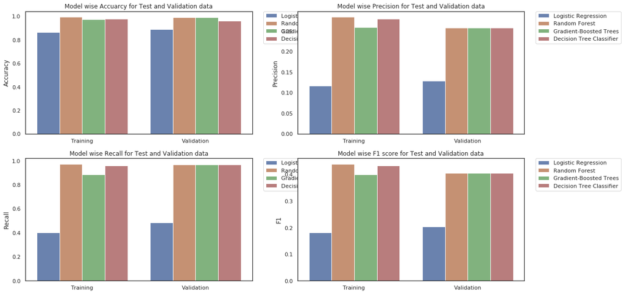

```python
# Plot metrics for algorithm
f, axes = plt.subplots(2, 2, figsize=(18, 10))

sbn.set(style="white", palette="muted", color_codes=True)

titles = [["Model wise Accuarcy for Test and Validation data", "Model wise Precision for Test and Validation data" ],
          ["Model wise Recall for Test and Validation data", "Model wise F1 score for Test and Validation data" ]
         ]

k = 0
for i,a in enumerate(axes):
    for j,ax in enumerate(a):
        ax = sbn.barplot(data=ml_metrics, x=ml_metrics.index, y=ml_metrics.columns[k], hue='model',
                         ax=axes[i,j], saturation=0.50);
        ax.set_title(titles[i][j]);
        ax.legend(bbox_to_anchor=(1.05, 1), loc=2, borderaxespad=0.);
        k += 1

# Put the legend out of the figure
plt.legend(bbox_to_anchor=(1.05, 1), loc=2, borderaxespad=0.);
plt.show();
```

```python
nt1 = pd.Timestamp.now()
print('NoteBook execution End time : {}'.format(nt1))
print('Total execution time : {} hh:mm:ss:ms'.format(nt1 - nt0 ))
```

```
NoteBook execution End time : 2020-08-08 10:31:52.260692
Total execution time : 0 days 01:06:26.257788 hh:mm:ss:ms
```

# Conclusion

Initial I set out to work with `mini-sparkify-event-data.json` to understand data with EDA and algorithm suitable for this data. I used 3 stagergies to model the data.

> 1. I used same set of features but with per day per user basis and trained the features with this model.
> 2. I used the same set of features but with per user basis without splitting them on per day basis with standard scaling of features.
> 3. I used the same set of features but with per user basis without splitting them on per day basis but without the standard scaling of features Strategy '3' gave a `f1` score of `0.51` with `mini-sparkify-event-data.json`

Further, The model also needs to be pacakged as class and pacakges for deployment.

```
                                                                  ** end of project **
```